# A clinical-epidemiology workflow in R

Real code and real output, one step at a time

Last updated

November 26, 2026

# Welcome

This is a small site about how I do clinical-epidemiology analysis in R. It is written for students who know a little Stata or a little R and want to see a whole workflow, starting from a messy spreadsheet.

The site grows over time. New chapters are added as the workflow goes further, so check the date at the top for the last update.

Chapters 1 to 4 run on one trial. Two drugs, A and B, are compared on fasting blood sugar (FBS) at months 0, 3, 6, 9 and 12. Each patient has up to five rows, so the visits of one patient are correlated. The data are a mock-up made for teaching. No real patient is involved. The file `data/README.md` describes the sheet and its layout. Chapters 5 to 7 move to a mock-up cohort of 600 patients who were not randomised, to teach the propensity score.

Each chapter takes one script and walks through it step by step. The code you read is loaded straight from the script file, so it is the code that ran. The output sits right under it. The script files keep their comments, and the page moves the ideas of those comments into the text beside the code.

R itself is described in the base R reference (R Core Team 2026). The page is built with Quarto, which runs the R code through knitr (Xie 2025) and rmarkdown (Allaire et al. 2026). Each package used later is cited in the chapter where it first appears, and the full list is at the end.

## The pipeline

```
flowchart LR
  A["Dirty Excel sheet<br/>(mock-up data)"] --> B["Clean<br/>one row per visit"]
  B --> C["Explore<br/>tables and plots"]
  C --> D["Table 1"]
  D -.-> E["Mixed model<br/>(coming)"]
  G["Cohort sheet<br/>(mock-up data)"] --> H["Propensity score<br/>and weights"]
  H --> I["Balance check"]
  I --> J["Effect of drug B<br/>marginal effect"]
  E -.-> F["more to come"]
  style E stroke-dasharray: 5 5
  style F stroke-dasharray: 5 5
```

| Chapter | Script | What it does |
| --- | --- | --- |
| 1 Cleaning a dirty Excel sheet | `code/1_clean_data.r` | Fixes dates, units, spellings and duplicates |
| 2 Exploring the data | `code/2_basic_explore.r` | Tables and plots, with epicalc and ggplot2 |
| 3 Table 1 with gtsummary | `code/3_table1.r` | A publication style baseline table |
| 4 Plots with ggplot2 | `code/4_ggplot_basics.r` | Basic plots, fitted curves, themes, axes and text, dodging |
| 5 Propensity score: the model and the weights | `code/5_ps_model.r` | PS model, IPTW weights, overlap and common support |
| 6 Propensity score: is the weighted cohort balanced? | `code/6_ps_balance.r` | SMD, love plot, mirror histogram, effective sample size, Table 1 with SMD |
| 7 Propensity score: the effect of drug B | `code/7_ps_effect.r` | Marginal effect with emmeans from six methods, against the known truth |
| Coming next |  | Mixed models for the repeated visits |

## Packages

```r
install.packages(c("dplyr", "tidyr", "readr", "stringr", "lubridate",
                   "readxl", "janitor", "ggplot2", "rstatix", "gtsummary", "gt",
                   "summarytools", "ragg", "cobalt", "survey", "emmeans", "MatchIt", "optmatch",
                   "sandwich", "broom", "forcats", "knitr", "rmarkdown"))
install.packages("epicalc", repos = c("https://medipe.psu.ac.th/epicalc",
                                      "https://cloud.r-project.org"))
```

The epicalc package is no longer on CRAN, so it comes from the repository above. You also need Quarto to build the page.

## How to run it

Get the pack from GitHub, at https://github.com/Nopkhongthon/clinepi-r-workflow. Click the green Code button, then Download ZIP, and unzip the folder. Open that folder as the project in Positron or RStudio, so that every path in the scripts starts from the project folder.

Run the seven scripts in this order. Then build the page.

```bash
Rscript code/1_clean_data.r
Rscript code/2_basic_explore.r
Rscript code/3_table1.r
Rscript code/4_ggplot_basics.r
Rscript code/5_ps_model.r
Rscript code/6_ps_balance.r
Rscript code/7_ps_effect.r
quarto render
```

Every script is also written to be run in cells, one `#%%@note step N:` block at a time, so you can stop after any step and look at the data.

# 1 Cleaning a dirty Excel sheet

| **Script** | `code/1_clean_data.r` |
| --- | --- |
| **In** | `data/fbs_mockup_trial.xlsx`, one row per patient |
| **Out** | `output/fbs_clean.rds`, one row per patient per visit |
| **How to run** | Step by step. Each step changes `df`, or `dfl` once the data are long. Re-run step 2 to start again. |

The sheet is a mock-up made for teaching. No real patient is involved.

## 1.1 About the dirty sheet

One row per patient, with a date column and an FBS column for each visit at months 0, 3, 6, 9 and 12. Several staff typed it, and it shows their habits.

| Kind of dirt | Example typed in the sheet | Fixed in step |
| --- | --- | --- |
| Patient number in many styles | `32`, `004`, `FBS-015` | 3 |
| Rows entered twice | the same patient on two rows | 4 |
| Many spellings of one group | `a`, `drug a`, `ยา a`, `group a` | 5, 6 |
| Many spellings of one sex | `1`, `M`, `male`, `ชาย` | 5, 7 |
| Units inside the cell | `62 ปี`, `27.3 kg/m2`, `5 yr` | 8 |
| Impossible values | age `999`, BMI `273` | 9 |
| mmol/L in the mg/dL column | `7.2` | 12 |
| Missing-value codes | `999`, `N/A`, `ไม่มา` | 1, 12 |
| Mixed date formats | `23 มิ.ย. 2568`, `45838`, `2025-06-30` | 13 |
| A mistyped year | a visit after the study closed | 13 |

## 1.2 Step 1: packages, paths and lookups

To install a missing package, remove the `#` in front of the `install.packages()` line and run it once.

| Package | Its one job here |
| --- | --- |
| readxl (Wickham and Bryan 2026) | Read the Excel sheet |
| janitor (Firke 2024) | `clean_names()`, and turn Excel serial numbers into dates |
| readr (Wickham, Hester, and Bryan 2026) | `parse_number()`, the number out of text such as `62 ปี` |
| dplyr (Wickham, François, et al. 2026) | The verbs of the cleaning chain |
| tidyr (Wickham, Vaughan, and Girlich 2025) | `pivot_longer()`, one row per patient becomes one row per visit |
| stringr (Wickham 2025b) | Match the free text fields |
| lubridate (Spinu, Grolemund, and Wickham 2026) | Parse the dates |

The three lookups hold what I already know about the mess.

| Lookup | Holds | Example |
| --- | --- | --- |
| `na_codes` | Text that means no value | `N/A`, `-`, `ไม่มา` (did not come) |
| `thai_month` | Thai month name to a month number | `23 มิ.ย. 2568` → `23/6/2568` |
| `study_close` | The day the study closed | No real visit falls after it |

The dots in the Thai month names are escaped. `str_replace_all()` reads the names as regular expressions, and a bare dot matches any character.

```r
library(readxl)
library(janitor)
library(readr)
library(dplyr)
library(tidyr)
library(stringr)
library(lubridate)

path_raw   <- "data/fbs_mockup_trial.xlsx"
path_clean <- "output/fbs_clean.rds"

na_codes <- c("", " ", ".", "-", "N/A", "NA", "na", "ไม่มา")

thai_month <- c(
  "มี\\.ค\\." = "/3/",  "เม\\.ย\\." = "/4/",  "มิ\\.ย\\." = "/6/",
  "ม\\.ค\\."  = "/1/",  "ก\\.พ\\."  = "/2/",  "พ\\.ค\\."  = "/5/",
  "ก\\.ค\\."  = "/7/",  "ส\\.ค\\."  = "/8/",  "ก\\.ย\\."  = "/9/",
  "ต\\.ค\\."  = "/10/", "พ\\.ย\\."  = "/11/", "ธ\\.ค\\."  = "/12/"
)

study_close <- as.Date("2026-06-30")
```

## 1.3 Step 2: import the sheet as text

Almost every column mixes numbers with words. So readxl does not guess the types. Every column comes in as text and gets its type later, in a step you can see.

```r
df <- readxl::read_excel(
  path_raw,
  sheet     = "data",
  col_types = "text",
  na        = na_codes
) |>
  janitor::clean_names()
```

| id | group | age | sex | bmi | dm_duration_yr | date_m0 | fbs_m0 | date_m3 | fbs_m3 | date_m6 | fbs_m6 | date_m9 | fbs_m9 | date_m12 | fbs_m12 |
| --- | --- | --- | --- | --- | --- | --- | --- | --- | --- | --- | --- | --- | --- | --- | --- |
| 097 | Drug A | 56 | M | 27 | 6 | 2024-11-20 | 116 | 2025-03-05 | 146 | 2025-06-04 | 146 | 2025-09-02 | 141 | 2025-11-08 | 136 |
| 154 | ยา B | 60 | 1 | 31.3 | 6 | 01/12/2024 | 190 | 10/03/2025 | 177 | 25/05/2025 | 199 | 01/09/2025 | 191 | 25/11/2025 | 195 |
| 148 | Drug B | 58 | หญิง | 22.7 | 4 | 01/12/2567 | 139 | 17/02/2568 | 146 | 26/05/2568 | 88 | 03/09/2568 | 98 | 08/12/2568 | 94 |
| 184 | Drug A | 67 | NA | 28.4 | 14 | 45611 | 215 | 45695 | 197 | 45797 | 183 | 45874 | 177 | 45971 | 157 |
| FBS-116 | Drug B | 72 | female | 22.3 | 8 | 45471 | 141 | 45555 | 121 | 45656 | 106 | 45740 | 132 | 45825 | 126 |
| 122 | drug A | 37 ปี | m | 27.9 | 20 | 08/10/2567 | 192 | 12/01/2568 | 147 | 06/04/2568 | 159 | 07/07/2568 | 138 | 28/09/2568 | 159 |
| 136 | group B | 44 | 0 | 21.9 | 1 | 45654 | 115 | 45746 | 71 mg/dL | 45838 | 73 | 45920 | 49 | 46009 | 69 |
| 38 | group B | 54 | male | 24.7 | 2 | 2024-07-21 | 156 | 2024-11-03 | 119 | 2025-01-19 | 124 | 2025-04-29 | 116 | 2025-07-31 | 126 |

The sheet has 203 rows and 16 columns.

## 1.4 Step 3: clean the patient id

Keep only the digits.

| Typed | Becomes |
| --- | --- |
| `32` | 32 |
| `004` | 4 |
| `FBS-015` | 15 |

```r
df <- df |>
  dplyr::mutate(id = as.integer(stringr::str_extract(id, "\\d+")))
```

## 1.5 Step 4: drop duplicate records

| Kind of duplicate | Rule |
| --- | --- |
| Identical in every field | Drop the copy |
| Same patient, one value typed differently | Keep the first row, and name the patient so the data collector can check the paper form |

```r
df <- dplyr::distinct(df)

dup_id <- df$id[duplicated(df$id)]

df <- dplyr::slice_head(df, n = 1, by = id)
```

`dup_id` holds 1 patient, id 105. After this step 200 patients remain, one row each.

## 1.6 Step 5: put every free text field on one spelling

Squish the spaces and lower the case before writing any rule.

| Typed | After step 5 |
| --- | --- |
| `" M "` | `m` |
| `MALE` | `male` |
| `Drug A` | `drug a` |

Each rule in steps 6 and 7 then has fewer spellings to match.

```r
df <- df |>
  dplyr::mutate(
    dplyr::across(
      c(group, sex),
      function(x) {
        stringr::str_to_lower(stringr::str_squish(x))
      }
    )
  )
```

## 1.7 Step 6: treatment arm

Every spelling ends in the letter of the arm, so one pattern covers them all.

| Spellings | Becomes |
| --- | --- |
| `a`, `drug a`, `ยา a`, `group a` | A |
| `b`, `drug b`, `ยา b`, `group b` | B |

```r
df <- df |>
  dplyr::mutate(
    treatment = dplyr::case_when(
      stringr::str_detect(group, "^(drug |ยา |group )?a$") ~ "A",
      stringr::str_detect(group, "^(drug |ยา |group )?b$") ~ "B"
    ) |>
      factor(levels = c("A", "B"))
  )
```

```
#>
#>   A   B
#> 100 100
```

## 1.8 Step 7: sex

| Spellings | Becomes |
| --- | --- |
| `1`, `m`, `male`, `ชาย` | Male |
| `0`, `f`, `female`, `หญิง` | Female |

```r
df <- df |>
  dplyr::mutate(
    sex = dplyr::case_when(
      stringr::str_detect(sex, "^(1|m|male|ชาย)$")    ~ "Male",
      stringr::str_detect(sex, "^(0|f|female|หญิง)$") ~ "Female"
    ) |>
      factor(levels = c("Female", "Male"))
  )
```

```
#>
#> Female   Male   <NA>
#>    107     91      2
```

## 1.9 Step 8: age, BMI and diabetes duration become numbers

`parse_number()` keeps the number and drops the unit.

| Typed | Becomes |
| --- | --- |
| `62 ปี` | 62 |
| `27.3 kg/m2` | 27.3 |
| `5 yr` | 5 |

```r
df <- df |>
  dplyr::mutate(
    dplyr::across(
      c(age, bmi, dm_duration_yr),
      function(x) {
        readr::parse_number(x)
      }
    )
  ) |>
  dplyr::rename(dm_duration = dm_duration_yr)
```

## 1.10 Step 9: impossible values

The patients are saved in `bad_baseline` first, so their ids stay on record after the values change.

| Variable | Rule | Why |
| --- | --- | --- |
| Age | Outside 18 to 100 → missing | 999 is a missing code, and an adult trial has nobody aged 6 |
| BMI | Above 100 → divide by 10 | The decimal point was lost, so 273 was 27.3 |
| Diabetes duration | 99 or more → missing | 99 is a missing code |

```r
bad_baseline <- df |>
  dplyr::filter(!dplyr::between(age, 18, 100) | bmi > 100 | dm_duration >= 99) |>
  dplyr::select(id, age, bmi, dm_duration)

df <- df |>
  dplyr::mutate(
    age = dplyr::if_else(dplyr::between(age, 18, 100), age, NA_real_),
    bmi = dplyr::if_else(bmi > 100, bmi / 10, bmi),
    dm_duration = dplyr::if_else(dm_duration >= 99, NA_real_, dm_duration)
  )
```

5 patients have an impossible baseline value.

## 1.11 Step 10: wide to long, and back

A mixed model needs one row per visit. The two functions are a pair, and each undoes the other.

```
flowchart LR
  W["<b>Wide</b>, one row per patient<br/>id · date_m0 · fbs_m0 · date_m3 · fbs_m3 · …"]
  L["<b>Long</b>, one row per visit<br/>id · month · date · fbs"]
  W -- "pivot_longer()<br/>fbs_m3 → fbs + month 3" --> L
  L -- "pivot_wider()<br/>fbs + month 3 → fbs_m3" --> W
```

|  | `pivot_longer()` | `pivot_wider()` |
| --- | --- | --- |
| Direction | Wide → long | Long → wide |
| Which columns move | `cols`, every `date_m*` and `fbs_m*` | `values_from = c(date, fbs)` |
| Column name | Split by `names_pattern` into `.value` + `month` | Built by `names_glue = "{.value}_m{month}"` |
| Result here | `dfl`, used from now on | `dfw`, a look only |
| Stata | `reshape long` | `reshape wide` |

`.value` means that part of the name becomes the column name, so `fbs_m3` lands in a column called `fbs`.

```r
dfl <- df |>
  dplyr::select(
    id, treatment, age, sex, bmi, dm_duration,
    dplyr::matches("^(date|fbs)_m\\d+$")
  ) |>
  tidyr::pivot_longer(
    cols            = dplyr::matches("^(date|fbs)_m\\d+$"),
    names_pattern   = "(date|fbs)_m(\\d+)",
    names_to        = c(".value", "month"),
    names_transform = list(month = as.integer)
  )

dfw <- dfl |>
  tidyr::pivot_wider(
    names_from  = month,
    values_from = c(date, fbs),
    names_glue  = "{.value}_m{month}",
    names_vary  = "slowest"
  )
```

| id | treatment | age | sex | bmi | dm_duration | month | date | fbs |
| --- | --- | --- | --- | --- | --- | --- | --- | --- |
| 97 | A | 56 | Male | 27.0 | 6 | 0 | 2024-11-20 | 116 |
| 97 | A | 56 | Male | 27.0 | 6 | 3 | 2025-03-05 | 146 |
| 97 | A | 56 | Male | 27.0 | 6 | 6 | 2025-06-04 | 146 |
| 97 | A | 56 | Male | 27.0 | 6 | 9 | 2025-09-02 | 141 |
| 97 | A | 56 | Male | 27.0 | 6 | 12 | 2025-11-08 | 136 |
| 154 | B | 60 | Male | 31.3 | 6 | 0 | 01/12/2024 | 190 |
| 154 | B | 60 | Male | 31.3 | 6 | 3 | 10/03/2025 | 177 |
| 154 | B | 60 | Male | 31.3 | 6 | 6 | 25/05/2025 | 199 |

1000 rows, which is 200 patients × 5 planned visits. Going back, `dfw` has 200 rows again, one per patient.

| id | treatment | age | sex | bmi | dm_duration | date_m0 | fbs_m0 | date_m3 | fbs_m3 | date_m6 | fbs_m6 | date_m9 | fbs_m9 | date_m12 | fbs_m12 |
| --- | --- | --- | --- | --- | --- | --- | --- | --- | --- | --- | --- | --- | --- | --- | --- |
| 97 | A | 56 | Male | 27.0 | 6 | 2024-11-20 | 116 | 2025-03-05 | 146 | 2025-06-04 | 146 | 2025-09-02 | 141 | 2025-11-08 | 136 |
| 154 | B | 60 | Male | 31.3 | 6 | 01/12/2024 | 190 | 10/03/2025 | 177 | 25/05/2025 | 199 | 01/09/2025 | 191 | 25/11/2025 | 195 |
| 148 | B | 58 | Female | 22.7 | 4 | 01/12/2567 | 139 | 17/02/2568 | 146 | 26/05/2568 | 88 | 03/09/2568 | 98 | 08/12/2568 | 94 |
| 184 | A | 67 | NA | 28.4 | 14 | 45611 | 215 | 45695 | 197 | 45797 | 183 | 45874 | 177 | 45971 | 157 |

## 1.12 Step 11: drop the visits that never happened

| Visit row | Meaning | Action |
| --- | --- | --- |
| No date and no FBS | The patient stopped coming. Dropout, not dirt | Drop the row |
| Date or FBS present | The visit happened | Keep |

A mixed model uses the visits that did happen. It stays valid when dropout depends only on values we saw, which is missing at random (MAR).

```r
dfl <- dfl |>
  dplyr::filter(!(is.na(date) & is.na(fbs)))
```

912 visits remain.

## 1.13 Step 12: FBS becomes a number on one unit

The glucometer shows mmol/L and the lab reports mg/dL. Staff typed both into one column, so the size of the number tells the unit.

| Typed value | Read as | Action | Example |
| --- | --- | --- | --- |
| Below 30 | mmol/L | × 18 (1 mmol/L glucose = 18 mg/dL) | `7.2` → 130 |
| 30 to 600 | mg/dL | Keep | `126` → 126 |
| Above 600 | Missing code | Missing | `999` → NA |

The typed text is kept in `fbs_typed`, so every changed value can be listed with its id.

```r
dfl <- dfl |>
  dplyr::mutate(
    fbs_typed = fbs,
    fbs       = readr::parse_number(fbs),
    fbs       = dplyr::if_else(fbs < 30, round(fbs * 18), fbs),
    fbs       = dplyr::if_else(fbs > 600, NA_real_, fbs)
  )

fbs_fixed <- dfl |>
  dplyr::filter(
    readr::parse_number(fbs_typed) < 30 | readr::parse_number(fbs_typed) > 600
  ) |>
  dplyr::select(id, month, fbs_typed, fbs)
```

13 values were converted or set to missing.

## 1.14 Step 13: visit dates, one habit per line

Each line fixes one habit and leaves the text ready for the next line.

| Line | Habit | Typed | After the line |
| --- | --- | --- | --- |
| 1 | Thai month name | `23 มิ.ย. 2568` | `23/6/2568` |
| 2 | Excel serial number, five digits | `45838` | `30/06/2025` |
| 3 | Buddhist Era year, above 2400 | `23/6/2568` | `23/6/2025` |
| 4 | Day first or year first | `23/6/2025`, `2025-06-23` | a date, via `dmy()` then `ymd()` |
| 5 | Visit after the study closed | a mistyped year | missing |

After the step, look at `date` and `txt` side by side. That comparison is the whole lesson. A date still missing here had something typed in the sheet, so the step names those rows for the data collector and keeps them.

```r
dfl <- dfl |>
  dplyr::mutate(
    txt = stringr::str_squish(date),

    txt = stringr::str_replace_all(txt, thai_month),
    txt = stringr::str_remove_all(txt, " "),

    serial = dplyr::if_else(stringr::str_detect(txt, "^\\d{5}$"), txt, NA_character_),
    txt    = dplyr::if_else(
      !is.na(serial),
      format(janitor::excel_numeric_to_date(as.numeric(serial)), "%d/%m/%Y"),
      txt
    ),

    year = as.integer(stringr::str_extract(txt, "\\d{4}")),
    txt = dplyr::if_else(
      year > 2400,
      stringr::str_replace(txt, "\\d{4}", as.character(year - 543)),
      txt,
      missing = txt
    ),

    visit_date = dplyr::coalesce(
      lubridate::dmy(txt, quiet = TRUE),
      lubridate::ymd(txt, quiet = TRUE)
    ),

    visit_date = dplyr::if_else(
      visit_date > study_close,
      as.Date(NA),
      visit_date,
      missing = visit_date
    )
  )

date_bad <- dfl |>
  dplyr::filter(is.na(visit_date), !is.na(date)) |>
  dplyr::select(id, month, date)
```

1 visit date could not be used.

## 1.15 Step 14: time since the first visit

Month 3 is the plan. The real visit can be a few days early or late.

| New column | What it holds |
| --- | --- |
| `days` | Actual days since the month 0 visit |
| `time_months` | Actual calendar months since month 0. Falls back to the planned month when the date is missing |
| due date | Month 0 date + planned months |

| Detail | Example |
| --- | --- |
| lubridate counts real calendar months | 15 Jan → 15 Apr = exactly 3 |
| `%m+%` stays inside the month | 31 Jan + 1 month = 28 or 29 Feb, not March |
| Write `period(month = month)` | `period(month, units = "months")` adds the whole column into one period, so every visit gets the same due date |

Visits more than 3 weeks from their due date go into `off_window` for a look.

```r
dfl <- dfl |>
  dplyr::mutate(
    date_m0     = visit_date[month == 0],
    days        = as.numeric(visit_date - date_m0),
    time_months = round(
      lubridate::time_length(
        lubridate::interval(date_m0, visit_date),
        unit = "months"
      ),
      2
    ),
    time_months = dplyr::coalesce(time_months, as.numeric(month)),
    due_date    = date_m0 %m+% lubridate::period(month = month),
    .by = id
  )

off_window <- dfl |>
  dplyr::filter(abs(as.numeric(visit_date - due_date)) > 21) |>
  dplyr::select(id, month, due_date, visit_date)
```

`off_window` holds 0 visits.

## 1.16 Step 15: keep the analysis variables

Only the variables the analysis needs, in a sensible order.

```r
dfl <- dfl |>
  dplyr::select(
    id, treatment, age, sex, bmi, dm_duration,
    month, visit_date, days, time_months, fbs
  ) |>
  dplyr::arrange(id, month)
```

| id | treatment | age | sex | bmi | dm_duration | month | visit_date | days | time_months | fbs |
| --- | --- | --- | --- | --- | --- | --- | --- | --- | --- | --- |
| 1 | A | 62 | Female | 27.3 | 2 | 0 | 2024-11-25 | 0 | 0.00 | 162 |
| 1 | A | 62 | Female | 27.3 | 2 | 3 | 2025-02-16 | 83 | 2.71 | 141 |
| 1 | A | 62 | Female | 27.3 | 2 | 6 | 2025-05-28 | 184 | 6.10 | 142 |
| 1 | A | 62 | Female | 27.3 | 2 | 9 | 2025-09-07 | 286 | 9.42 | 136 |
| 1 | A | 62 | Female | 27.3 | 2 | 12 | 2025-11-17 | 357 | 11.74 | 142 |
| 2 | B | 46 | Male | 25.5 | 9 | 0 | 2024-10-24 | 0 | 0.00 | 145 |
| 2 | B | 46 | Male | 25.5 | 9 | 3 | 2025-01-15 | 83 | 2.71 | 133 |
| 2 | B | 46 | Male | 25.5 | 9 | 6 | 2025-05-02 | 190 | 6.27 | 106 |

## 1.17 Step 16: check

The script stops if a cleaned number does not match what is known for this dataset. A wrong cleaning rule would break one of these.

| Check | Expected |
| --- | --- |
| Patients and visits | The known totals |
| Month 0 visit | Every patient has one |
| Duplicate visits | None |
| Months | Only 0, 3, 6, 9, 12 |
| Treatment | No missing |
| Sex | Two levels |
| FBS | 40 to 400 mg/dL |
| Days since month 0 | Never negative |

```r
stopifnot(
  dplyr::n_distinct(dfl$id) == 200,
  nrow(dfl) == 912,
  sum(dfl$month == 0) == 200,
  nrow(dplyr::distinct(dfl, id, month)) == nrow(dfl),
  all(dfl$month %in% c(0, 3, 6, 9, 12)),
  !any(is.na(dfl$treatment)),
  nlevels(dfl$sex) == 2,
  all(dplyr::between(dfl$fbs, 40, 400), na.rm = TRUE),
  all(dfl$days >= 0, na.rm = TRUE)
)
```

The cleaned data hold 200 patients and 912 visits.

## 1.18 Step 17: describe the cleaned data

A last look at every variable with summarytools (Comtois 2026).

```r
summarytools::dfSummary(dfl)
```

Data Frame Summary  
dfl  
Dimensions: 912 x 11  
Duplicates: 0

| No | Variable | Stats / Values | Freqs (% of Valid) | Graph | Valid | Missing |
| --- | --- | --- | --- | --- | --- | --- |
| 1 | id [integer] | Mean (sd) : 102.2 (57.8) min < med < max: 1 < 103 < 200 IQR (CV) : 100.2 (0.6) | 200 distinct values | . . . . . : . : . : : : : : : : : : : : : : : : : : : : : : : : : : : : : : : : : : : : : : : : : : | 912 (100.0%) | 0 (0.0%) |
| 2 | treatment [factor] | 1. A 2. B | 455 (49.9%) 457 (50.1%) | IIIIIIIII IIIIIIIIII | 912 (100.0%) | 0 (0.0%) |
| 3 | age [numeric] | Mean (sd) : 57 (9.7) min < med < max: 30 < 57 < 87 IQR (CV) : 14 (0.2) | 42 distinct values | : : : . : : : : : : : . . . : : : : : : . | 893 (97.9%) | 19 (2.1%) |
| 4 | sex [factor] | 1. Female 2. Male | 494 (54.8%) 408 (45.2%) | IIIIIIIIII IIIIIIIII | 902 (98.9%) | 10 (1.1%) |
| 5 | bmi [numeric] | Mean (sd) : 26.5 (4) min < med < max: 16.1 < 26.6 < 37.4 IQR (CV) : 5.4 (0.2) | 113 distinct values | . : : . : : : : : : : : : : : : : : : : : : : . | 912 (100.0%) | 0 (0.0%) |
| 6 | dm_duration [numeric] | Mean (sd) : 8 (5.6) min < med < max: 1 < 6 < 29 IQR (CV) : 7 (0.7) | 24 distinct values | . : : : : : : . : : : : . : : : : : : . . | 907 (99.5%) | 5 (0.5%) |
| 7 | month [integer] | Mean (sd) : 5.8 (4.3) min < med < max: 0 < 6 < 12 IQR (CV) : 6 (0.7) | 0 : 200 (21.9%) 3 : 187 (20.5%) 6 : 181 (19.8%) 9 : 174 (19.1%) 12 : 170 (18.6%) | IIII IIII III III III | 912 (100.0%) | 0 (0.0%) |
| 8 | visit_date [Date] | min : 2024-01-08 med : 2025-01-03 max : 2026-01-16 range : 2y 0m 8d | 484 distinct values | . : : : : : : . : : : : : : . : : : : : : : : : : : : : : : : : : | 911 (99.9%) | 1 (0.1%) |
| 9 | days [numeric] | Mean (sd) : 175.3 (130.1) min < med < max: 0 < 181 < 379 IQR (CV) : 198 (0.7) | 116 distinct values | : . . : : : : : : : : : : : : : : : : : . : : : | 907 (99.5%) | 5 (0.5%) |
| 10 | time_months [numeric] | Mean (sd) : 5.8 (4.3) min < med < max: 0 < 6 < 12.5 IQR (CV) : 6.5 (0.7) | 221 distinct values | : . : : . : : : : : : : : : : : : : : : : . : : | 912 (100.0%) | 0 (0.0%) |
| 11 | fbs [numeric] | Mean (sd) : 147.9 (27.6) min < med < max: 49 < 146 < 249 IQR (CV) : 36 (0.2) | 137 distinct values | : : : : : : . : : : : . : : : : : : | 911 (99.9%) | 1 (0.1%) |

## 1.19 Step 18: save

An RDS file keeps every variable type exactly. The next chapters start from it.

```r
saveRDS(dfl, path_clean)
```

# 2 Exploring the data

Before any model I look at the data with simple tables and plots. Most of the tables come from epicalc, the package that brings Stata style commands to R. The pictures come from ggplot2.

The script is `code/2_basic_explore.r`. It reads the cleaned file from chapter 1, builds the result tables and saves them as `output/fbs_explore.rds`. It changes nothing in the data. A later script, not written yet, will answer the main question with a mixed model. Does FBS fall more on drug B than on drug A over 12 months?

## 2.1 Step 1: packages and paths

Five packages are loaded, and each has one job. The epicalc package (Chongsuvivatwong 2023) gives `tab1()`, `tabpct()`, `tableStack()` and `aggregate()`, which make the tables. It left CRAN in 2015, and a maintained version is hosted at https://medipe.psu.ac.th/epicalc. The script keeps the `install.packages()` lines for it and for the other packages as comments. The dplyr package (Wickham, François, et al. 2026) supplies `filter()` and `mutate()`. The tidyr package (Wickham, Vaughan, and Girlich 2025) supplies `pivot_wider()`, which gives one FBS column per visit in step 10. The ggplot2 package (Wickham, Chang, et al. 2026) draws the pictures. The rstatix package (Kassambara 2026) supplies `cor_test()`, which gives every Spearman pair with its p value, and epicalc has no such function.

Several of these packages define the same function name. The epicalc, MASS, dplyr and rstatix packages each have a `select()`. The epicalc package loads MASS by itself. The epicalc and dplyr packages each have a `recode()` and a `rename()`. The package loaded last wins, which is easy to get wrong, so every call in the script names its package.

```r
library(epicalc)
library(dplyr)
library(tidyr)
library(ggplot2)
library(rstatix)

path_clean   <- "output/fbs_clean.rds"
path_explore <- "output/fbs_explore.rds"
```

## 2.2 Step 2: load the cleaned data

The baseline characteristics repeat on every visit row, so I describe them from the month 0 rows only. That gives one row per patient. The epicalc package was written before tibbles, so it gets a plain data frame.

```r
dfl <- readRDS(path_clean)

df_base <- dfl |>
  dplyr::filter(month == 0) |>
  as.data.frame()
```

## 2.3 Step 3: baseline, the categorical variable

`tab1()` is Stata’s `tab sex`. It prints a frequency table with counts and percentages, with and without the missing, and draws a bar chart. The setting `horiz = TRUE` draws the bars sideways. The package then leaves 20% of extra room beside the longest bar, where upright bars get only 10%, so the count label of the longest bar is not cut off. The function fixes the axis limit itself, so a `ylim` argument is refused. `tabpct()` is Stata’s `tab treatment sex, row col`, the two-way table with row and column percentages. In a randomised trial the arms differ at baseline only by chance, so I look at balance by eye and show no p values. CONSORT advises against them.

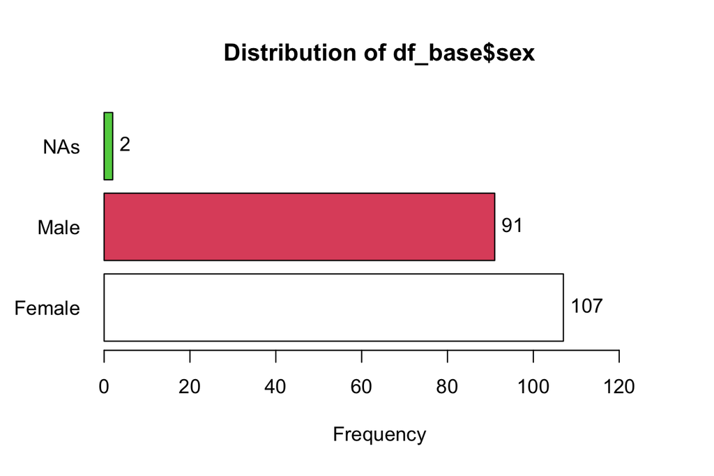

```r
tab_sex     <- epicalc::tab1(df_base$sex, horiz = TRUE)
```

```r
print(tab_sex)
```

```
#> df_base$sex :
#>         Frequency   %(NA+)   %(NA-)
#> Female        107     53.5       54
#> Male           91     45.5       46
#> NAs             2      1.0        0
#>   Total       200    100.0      100
```

```r
tab_sex_arm <- epicalc::tabpct(df_base$treatment, df_base$sex, graph = FALSE)
```

```
#>
#> Original table
#>                  df_base$sex
#> df_base$treatment  Female  Male  Total
#>             A          48    50     98
#>             B          59    41    100
#>             Total     107    91    198
#>
#> Row percent
#>                  df_base$sex
#> df_base$treatment  Female  Male  Total
#>                 A      48    50     98
#>                      (49)  (51)  (100)
#>                 B      59    41    100
#>                      (59)  (41)  (100)
#>
#> Column percent
#>                  df_base$sex
#> df_base$treatment  Female       %  Male       %
#>             A          48  (44.9)    50  (54.9)
#>             B          59  (55.1)    41  (45.1)
#>             Total     107   (100)    91   (100)
```

## 2.4 Step 4: baseline table, every variable by arm

`tableStack()` builds a whole baseline table in one call. It gives n (%) for factors and mean (SD) for numbers. The setting `test = FALSE` drops the p values, for the same CONSORT reason as in step 3. Left on automatic, the function picks median and interquartile range with a Shapiro test. A good rule is to judge by eye instead, so I look at the histograms of step 7 and name the skewed variable myself. Diabetes duration has a long right tail, so it gets the median.

```r
tab_base <- epicalc::tableStack(
  c(age, sex, bmi, dm_duration, fbs),
  dataFrame = df_base,
  by        = treatment,
  test      = FALSE,
  iqr       = c(dm_duration)
)

print(tab_base)
```

```
#>               A          B
#> Total         100        100
#>
#> age
#>   mean(SD)    57 (10.1)  57.1 (9.2)
#>
#> sex
#>    Female     48 (49)    59 (59)
#>    Male       50 (51)    41 (41)
#>
#> bmi
#>   mean(SD)    26.7 (3.9) 26.8 (4.1)
#>
#> dm_duration
#>   median(IQR) 7 (4,12)   7 (4,10)
#>
#> fbs
#>   mean(SD)    169.7 (22) 170.4 (28.2)
#>
```

## 2.5 Step 5: who came to each visit

The dropout pattern is visits by month, in the rows, and by arm, in the columns. A mixed model keeps every visit a patient did attend. A patient who left at month 6 still counts for months 0 and 3.

```r
tab_visits <- epicalc::tabpct(dfl$month, dfl$treatment, graph = FALSE)
```

```
#>
#> Original table
#>          dfl$treatment
#> dfl$month    A    B  Total
#>     0      100  100    200
#>     3       96   91    187
#>     6       91   90    181
#>     9       85   89    174
#>     12      83   87    170
#>     Total  455  457    912
#>
#> Row percent
#>          dfl$treatment
#> dfl$month       A       B  Total
#>        0      100     100    200
#>              (50)    (50)  (100)
#>        3       96      91    187
#>            (51.3)  (48.7)  (100)
#>        6       91      90    181
#>            (50.3)  (49.7)  (100)
#>        9       85      89    174
#>            (48.9)  (51.1)  (100)
#>        12      83      87    170
#>            (48.8)  (51.2)  (100)
#>
#> Column percent
#>          dfl$treatment
#> dfl$month    A       %    B       %
#>     0      100  (22.0)  100  (21.9)
#>     3       96  (21.1)   91  (19.9)
#>     6       91  (20.0)   90  (19.7)
#>     9       85  (18.7)   89  (19.5)
#>     12      83  (18.2)   87  (19.0)
#>     Total  455   (100)  457   (100)
```

## 2.6 Step 6: FBS at each visit, by arm

This table is the trial in numbers. Both arms start near the same level, and then I watch how far each one falls. The `aggregate()` function of epicalc takes several statistics at once in its `FUN` argument.

```r
tab_fbs <- epicalc::aggregate.numeric(
  dfl$fbs,
  by  = list(treatment = dfl$treatment, month = dfl$month),
  FUN = c("mean", "sd", "count")
)
```

```
#>
#>  Note:
#>       Missing values removed.
```

```r
print(tab_fbs)
```

```
#>    treatment month mean.dfl.fbs sd.dfl.fbs count.dfl$fbs
#> 1          A     0     169.6600   21.98632           100
#> 2          B     0     170.3800   28.22270           100
#> 3          A     3     156.2917   22.12496            96
#> 4          B     3     147.1978   24.82034            91
#> 5          A     6     148.2857   19.66513            91
#> 6          B     6     135.9101   25.02982            89
#> 7          A     9     142.5529   22.39181            85
#> 8          B     9     130.2022   25.38350            89
#> 9          A    12     143.2410   20.30294            83
#> 10         B    12     127.7816   25.52219            87
```

## 2.7 Step 7: are the baseline variables roughly normal? Judge by eye

Before choosing how to summarise each baseline number, I look at its shape. The histograms and box plots below cover age, body mass index and diabetes duration. Each panel has its own scale and its own axes, set with `scales = "free"`, because the three variables have different units. Age and body mass index are roughly symmetric, with the median near the middle of the box. Diabetes duration has a long right tail, with a few long durations marked as dots. That is why it gets the median later on and the other two get the mean.

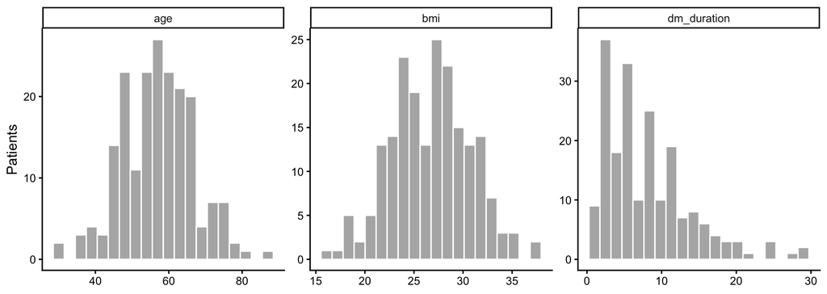

```r
df_base_long <- df_base |>
  dplyr::select(age, bmi, dm_duration) |>
  tidyr::pivot_longer(dplyr::everything(), names_to = "variable", values_to = "value")

p_base_hist <- ggplot2::ggplot(df_base_long, ggplot2::aes(x = value)) +
  ggplot2::geom_histogram(bins = 20, fill = "grey70", colour = "white") +
  ggplot2::facet_wrap(~ variable, scales = "free", axes = "all", axis.labels = "all") +
  ggplot2::labs(x = NULL, y = "Patients") +
  ggplot2::theme_classic()

p_base_box <- ggplot2::ggplot(df_base_long, ggplot2::aes(y = value)) +
  ggplot2::geom_boxplot(fill = "grey85") +
  ggplot2::facet_wrap(~ variable, scales = "free", axes = "all", axis.labels = "all") +
  ggplot2::labs(y = NULL) +
  ggplot2::theme_classic() +
  ggplot2::theme(
    axis.text.x = ggplot2::element_blank(),
    axis.ticks.x = ggplot2::element_blank()
  )

p_base_hist
```

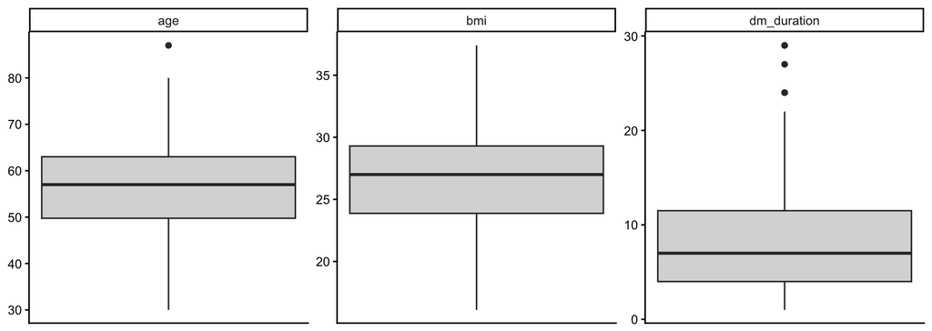

```r
p_base_box
```

## 2.8 Step 8: is FBS roughly normal? Judge by eye

I judge normality by eye and not by a test. A histogram and a box plot of the variable show the shape directly, and a formal test mostly reflects the sample size. The same rule holds for FBS itself, at every visit. The setting `axes = "all"` draws the x and y axis on every panel, not just the outer ones. The panels still share one scale, so they stay comparable.

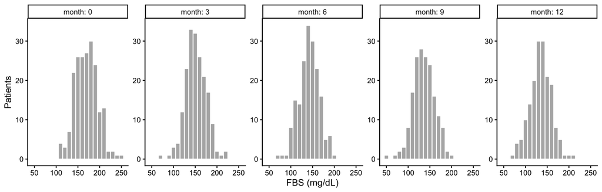

```r
p_hist <- ggplot2::ggplot(dfl, ggplot2::aes(x = fbs)) +
  ggplot2::geom_histogram(binwidth = 10, fill = "grey70", colour = "white") +
  ggplot2::facet_wrap(
    ~ month,
    nrow = 1,
    labeller = ggplot2::label_both,
    axes = "all",
    axis.labels = "all"
  ) +
  ggplot2::labs(x = "FBS (mg/dL)", y = "Patients") +
  ggplot2::theme_classic()

p_box <- ggplot2::ggplot(
  dfl,
  ggplot2::aes(x = factor(month), y = fbs, fill = treatment)
) +
  ggplot2::geom_boxplot() +
  ggplot2::labs(x = "Month", y = "FBS (mg/dL)", fill = "Drug") +
  ggplot2::theme_classic()

p_hist
```

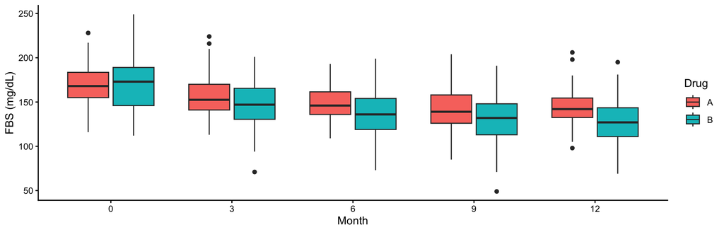

```r
p_box
```

## 2.9 Step 9: every patient’s own line

The spaghetti plot shows why a mixed model is needed. Each grey line is one patient. They start at different heights, which is the random intercept, and fall at different speeds, which is the random slope. The thick lines are the arm averages.

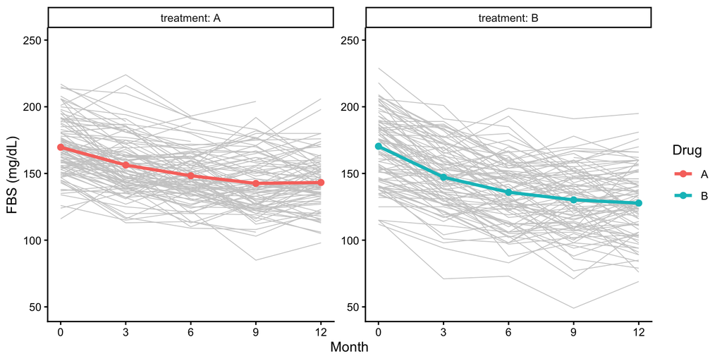

```r
p_spaghetti <- ggplot2::ggplot(dfl, ggplot2::aes(x = month, y = fbs)) +
  ggplot2::geom_line(ggplot2::aes(group = id), colour = "grey80", linewidth = 0.3) +
  ggplot2::stat_summary(
    ggplot2::aes(colour = treatment),
    fun = mean,
    geom = "line",
    linewidth = 1.2
  ) +
  ggplot2::stat_summary(
    ggplot2::aes(colour = treatment),
    fun = mean,
    geom = "point",
    size = 2
  ) +
  ggplot2::facet_wrap(
    ~ treatment,
    labeller = ggplot2::label_both,
    axes = "all",
    axis.labels = "all"
  ) +
  ggplot2::scale_x_continuous(breaks = c(0, 3, 6, 9, 12)) +
  ggplot2::labs(x = "Month", y = "FBS (mg/dL)", colour = "Drug") +
  ggplot2::theme_classic()

p_spaghetti
```

## 2.10 Step 10: visits of the same patient are correlated

Now one row per patient again, with one FBS column per visit. If visits were independent, Spearman’s rho between visits would be near zero. It is not, because a patient who is high at month 0 tends to stay high. That correlation is what a plain regression ignores and a mixed model handles. The filter `var1 < var2` compares the names as text. It drops each visit paired with itself and keeps one of each mirrored pair.

```r
cor_visits <- dfl |>
  dplyr::select(id, month, fbs) |>
  tidyr::pivot_wider(names_from = month, values_from = fbs, names_prefix = "fbs_m") |>
  rstatix::cor_test(
    vars = c("fbs_m0", "fbs_m3", "fbs_m6", "fbs_m9", "fbs_m12"),
    method = "spearman"
  ) |>
  dplyr::filter(var1 < var2) |>
  dplyr::select(var1, var2, rho = cor, p_value = p)

print(cor_visits, n = Inf)
```

```
#> # A tibble: 10 × 4
#>    var1    var2      rho  p_value
#>    <chr>   <chr>   <dbl>    <dbl>
#>  1 fbs_m0  fbs_m3   0.75 6.82e-35
#>  2 fbs_m0  fbs_m6   0.7  2.58e-27
#>  3 fbs_m0  fbs_m9   0.69 4.47e-26
#>  4 fbs_m0  fbs_m12  0.67 1.68e-23
#>  5 fbs_m3  fbs_m6   0.73 8.48e-32
#>  6 fbs_m3  fbs_m9   0.75 1.27e-32
#>  7 fbs_m6  fbs_m9   0.71 1.18e-27
#>  8 fbs_m12 fbs_m3   0.74 3.40e-30
#>  9 fbs_m12 fbs_m6   0.71 4.65e-27
#> 10 fbs_m12 fbs_m9   0.77 4.72e-34
```

## 2.11 Step 11: did the patients who left differ?

If the patients who dropped out had higher sugar, an analysis of completers would make both drugs look better than they are. This table compares the baseline FBS of completers and leavers.

```r
df_dropout <- dfl |>
  dplyr::mutate(completed = any(month == 12), .by = id) |>
  dplyr::filter(month == 0)

tab_dropout <- epicalc::aggregate.numeric(
  df_dropout$fbs,
  by  = list(treatment = df_dropout$treatment, completed = df_dropout$completed),
  FUN = c("mean", "sd", "count")
)

print(tab_dropout)
```

```
#>   treatment completed mean.df_dropout.fbs sd.df_dropout.fbs count.df_dropout$fbs
#> 1         A     FALSE            184.2353          22.85424                   17
#> 2         B     FALSE            196.4615          26.04680                   13
#> 3         A      TRUE            166.6747          20.70355                   83
#> 4         B      TRUE            166.4828          26.53425                   87
```

At baseline, patients who left before month 12 had a mean FBS of 190 mg/dL, against 167 mg/dL for patients who stayed. Those who left started higher, so dropout is related to the outcome and completers alone would give a flattering picture.

## 2.12 Step 12: check

The check stops the script if a number is off. It uses the numbers known from chapter 1, which are 200 patients and 912 visits. It also expects one row of FBS summary for each arm at each of the five visits, which is 10 rows. Finally, every pair of visits must have a rho, which gives 10 pairs.

```r
stopifnot(
  nrow(df_base) == 200,
  nrow(dfl) == 912,
  nrow(tab_fbs) == 2 * 5,
  nrow(cor_visits) == choose(5, 2)
)
```

## 2.13 Step 13: save

All the result tables go into one RDS list for later use.

```r
saveRDS(
  list(
    tab_sex = tab_sex,
    tab_sex_arm = tab_sex_arm,
    tab_base = tab_base,
    tab_visits = tab_visits,
    tab_fbs = tab_fbs,
    cor_visits = cor_visits,
    tab_dropout = tab_dropout
  ),
  path_explore
)
```

# 3 Table 1 with gtsummary

Almost every clinical paper starts with a baseline table. I build it in one call and then adjust it. Nothing in the table is typed by hand.

The script is `code/3_table1.r`. It reads the cleaned file from chapter 1. It saves the gtsummary object as `output/table1.rds`, to reuse or restyle later, and the table as `output/table1.docx`, ready to paste into a report. Every number in the table is computed by gtsummary. If the data change, re-run the script and the table changes with them.

## 3.1 Step 1: packages and paths

Three packages do the work. The dplyr package (Wickham, François, et al. 2026) has `filter()`, which keeps the baseline visit. The gtsummary package (Sjoberg et al. 2026) has `tbl_summary()`, which builds the whole Table 1 from one call. The gt package (Iannone et al. 2026) has `gtsave()`, which sends the table to Word. The script keeps the `install.packages()` line for these three as a comment.

```r
library(dplyr)
library(gtsummary)
library(gt)

path_clean <- "output/fbs_clean.rds"
path_rds   <- "output/table1.rds"
path_docx  <- "output/table1.docx"
```

## 3.2 Step 2: one row per patient

Table 1 describes patients as they entered the trial, so it uses the month 0 visit only. The long data repeat age and sex on every visit. Counting all 912 rows would count each patient up to five times.

```r
df_base <- readRDS(path_clean) |>
  dplyr::filter(month == 0)
```

## 3.3 Step 3: the basic table

First the default. `tbl_summary()` chooses a statistic for each variable by itself. I run this step alone first and look at the default.

```r
tbl1 <- df_base |>
  gtsummary::tbl_summary(
    include = c(age, sex, bmi, dm_duration, fbs),
    by      = treatment
  )

tbl1
```

| **Characteristic** | **A** N = 100<sup>1</sup> | **B** N = 100<sup>1</sup> |
| --- | --- | --- |
| age | 57 (50, 63) | 57 (49, 62) |
| Unknown | 3 | 1 |
| sex |  |  |
| Female | 48 (49%) | 59 (59%) |
| Male | 50 (51%) | 41 (41%) |
| Unknown | 2 | 0 |
| bmi | 26.9 (24.0, 29.3) | 27.4 (23.7, 29.6) |
| dm_duration | 7.0 (4.0, 12.0) | 7.0 (4.0, 10.0) |
| Unknown | 1 | 0 |
| fbs | 168 (155, 184) | 173 (146, 189) |

<sup>1</sup> Median (Q1, Q3); n (%)

## 3.4 Step 4: labels, statistics and missing data

Now I change only what I decided on purpose. The `statistic` argument gives the mean and standard deviation for the variables that looked symmetric in the histograms of chapter 2. It gives the median and quartiles (Q1, Q3) for diabetes duration, which has a long right tail. The choice is made by eye and not by a test. Diabetes duration was recorded in whole years, so it gets no decimals. The other numbers get one.

The setting `missing = "no"` removes the Unknown rows inside the table. Missing data get their own column instead. The `add_n()` function places that column right after the characteristic. It shows the missing count and its percentage of all 200 patients.

```r
tbl1 <- df_base |>
  gtsummary::tbl_summary(
    include = c(age, sex, bmi, dm_duration, fbs),
    by      = treatment,
    label   = list(
      age         ~ "Age (years)",
      sex         ~ "Sex",
      bmi         ~ "Body mass index (kg/m²)",
      dm_duration ~ "Diabetes duration (years)",
      fbs         ~ "Fasting blood sugar (mg/dL)"
    ),
    type      = list(age ~ "continuous", dm_duration ~ "continuous"),
    statistic = list(
      c(age, bmi, fbs) ~ "{mean} ({sd})",
      dm_duration      ~ "{median} ({p25}, {p75})",
      sex              ~ "{n} ({p}%)"
    ),
    digits    = list(c(age, bmi, fbs) ~ 1, dm_duration ~ 0),
    missing   = "no"
  ) |>
  gtsummary::add_n(
    statistic = "{N_miss} ({p_miss}%)",
    col_label = "**Missing data, n (%)**"
  )

tbl1
```

| **Characteristic** | **Missing data, n (%)** | **A** N = 100<sup>1</sup> | **B** N = 100<sup>1</sup> |
| --- | --- | --- | --- |
| Age (years) | 4 (2.0%) | 57.0 (10.1) | 57.1 (9.2) |
| Sex | 2 (1.0%) |  |  |
| Female |  | 48 (49%) | 59 (59%) |
| Male |  | 50 (51%) | 41 (41%) |
| Body mass index (kg/m²) | 0 (0%) | 26.7 (3.9) | 26.8 (4.1) |
| Diabetes duration (years) | 1 (0.5%) | 7 (4, 12) | 7 (4, 10) |
| Fasting blood sugar (mg/dL) | 0 (0%) | 169.7 (22.0) | 170.4 (28.2) |

<sup>1</sup> Mean (SD); n (%); Median (Q1, Q3)

## 3.5 Step 5: overall column, headers and title

I add an overall column with `add_overall()` and put the group size in each header. There are no p values. In a randomised trial any baseline difference is chance by design, so a test answers a question nobody asked. CONSORT says to leave them out.

The title has no “Table 1.” in the text, because Word numbers its tables itself. The caption set here shows in the Viewer pane. Step 7 adds it again for Word.

```r
table_title <- "Baseline characteristics by treatment arm"

tbl1 <- tbl1 |>
  gtsummary::add_overall(col_label = "**Overall**, N = {N}") |>
  gtsummary::modify_header(
    label          = "**Characteristic**",
    gtsummary::all_stat_cols(stat_0 = FALSE) ~ "**Drug {level}**, N = {n}"
  ) |>
  gtsummary::bold_labels() |>
  gtsummary::modify_caption(table_title)

tbl1
```

Baseline characteristics by treatment arm

| **Characteristic** | **Missing data, n (%)** | **Overall**, N = 200<sup>1</sup> | **Drug A**, N = 100<sup>1</sup> | **Drug B**, N = 100<sup>1</sup> |
| --- | --- | --- | --- | --- |
| Age (years) | 4 (2.0%) | 57.0 (9.6) | 57.0 (10.1) | 57.1 (9.2) |
| Sex | 2 (1.0%) |  |  |  |
| Female |  | 107 (54%) | 48 (49%) | 59 (59%) |
| Male |  | 91 (46%) | 50 (51%) | 41 (41%) |
| Body mass index (kg/m²) | 0 (0%) | 26.7 (4.0) | 26.7 (3.9) | 26.8 (4.1) |
| Diabetes duration (years) | 1 (0.5%) | 7 (4, 12) | 7 (4, 12) | 7 (4, 10) |
| Fasting blood sugar (mg/dL) | 0 (0%) | 170.0 (25.2) | 169.7 (22.0) | 170.4 (28.2) |

<sup>1</sup> Mean (SD); n (%); Median (Q1, Q3)

## 3.6 Step 6: check

The size in each column header comes from the data, so I check it against the numbers known from chapter 1.

```r
n_cols <- tbl1$table_styling$header |>
  dplyr::filter(column %in% c("stat_0", "stat_1", "stat_2")) |>
  dplyr::pull(modify_stat_n)

stopifnot(
  nrow(df_base) == 200,
  all(n_cols == c(200, 100, 100))
)
```

The overall column and the two drug columns hold 200, 100, 100 patients, in that order.

## 3.7 Step 7: save

The table is saved as an R object to restyle later, and as a Word file to paste into a report. The `as_gt()` function turns the gtsummary table into a gt table. The `gtsave()` function picks the file type from the extension, so `.docx` gives a Word file. It leaves the gtsummary caption out of a Word file, so the title goes in again as a gt header. Word shows it as a numbered caption, such as Table 1.

```r
saveRDS(tbl1, path_rds)

tbl1 |>
  gtsummary::as_gt() |>
  gt::tab_header(title = table_title) |>
  gt::gtsave(filename = path_docx)
```

# 4 Plots with ggplot2

This chapter teaches ggplot2 (Wickham, Chang, et al. 2026) on the same trial data. It starts with the basic plot types and then dresses one plot up until it is ready for a paper. The finished figure is saved as `output/figures/fbs_by_month.tiff`.

ggplot2 builds a plot in layers. You start with the data and say which column goes on which axis. Then you add a layer that draws, a layer that names things and a layer that sets the look. Each layer is joined with `+`.

| Layer | What it does |
| --- | --- |
| `ggplot(data, aes())` | Says which data to use, and which column goes on which axis |
| `geom_*()` | Says how to draw it, as points, lines, bars or fitted curves |
| `scale_*()` | Sets where the ticks go and the range of each axis |
| `labs()` | Gives the names of the axes, the legend and the title |
| `theme_*()` and `theme()` | Set the look, namely the background, the axis lines, and the size and face of the text |

Each step below adds one idea. Run a step, look at the plot, then go on.

The script is `code/4_ggplot_basics.r`. It reads the cleaned file from chapter 1.

## 4.1 Step 1: packages and paths

Three packages do the work. The dplyr package (Wickham, François, et al. 2026) has `filter()` and `summarise()`, which get the data ready for each plot. The ggplot2 package draws every plot in the script. The ragg package (Pedersen and Shemanarev 2026) has `agg_tiff()`, which writes a TIFF file that keeps its 300 dpi setting. The script keeps the `install.packages()` line for these three as a comment.

```r
library(dplyr)
library(ggplot2)
library(ragg)

path_clean <- "output/fbs_clean.rds"
path_fig   <- "output/figures/fbs_by_month.tiff"
```

## 4.2 Step 2: the data for the plots

Two small tables are made first. `df_base` has one row per patient, taken from the month 0 visit. `df_mean` has one row per arm per month, with the mean and the standard deviation (SD) of FBS. The line plot and the bar graph of means are drawn from this small table. The script prints it, so you can look at it.

```r
dfl <- readRDS(path_clean)

df_base <- dfl |>
  dplyr::filter(month == 0)

df_mean <- dfl |>
  dplyr::summarise(
    n        = sum(!is.na(fbs)),
    mean_fbs = mean(fbs, na.rm = TRUE),
    sd_fbs   = sd(fbs, na.rm = TRUE),
    .by      = c(treatment, month)
  )

df_mean
```

```
#> # A tibble: 10 × 5
#>    treatment month     n mean_fbs sd_fbs
#>    <fct>     <int> <int>    <dbl>  <dbl>
#>  1 A             0   100     170.   22.0
#>  2 A             3    96     156.   22.1
#>  3 A             6    91     148.   19.7
#>  4 A             9    85     143.   22.4
#>  5 A            12    83     143.   20.3
#>  6 B             0   100     170.   28.2
#>  7 B             3    91     147.   24.8
#>  8 B             6    89     136.   25.0
#>  9 B             9    89     130.   25.4
#> 10 B            12    87     128.   25.5
```

## 4.3 Step 3: a first scatter plot

Every plot needs three things. These are the data, `aes()` to say which column goes on the x axis and which on the y axis, and a geom to draw them. The function `geom_point()` draws one dot per row, so here one dot per patient.

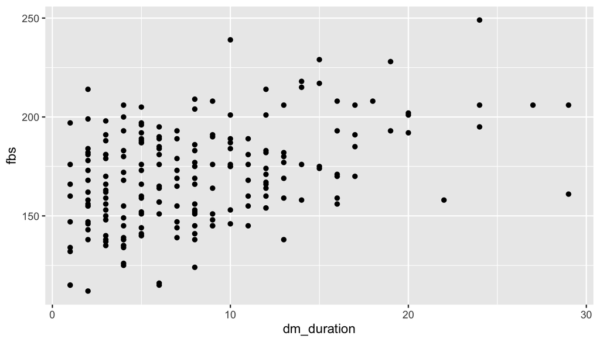

```r
p_scatter <- ggplot2::ggplot(df_base, ggplot2::aes(x = dm_duration, y = fbs)) +
  ggplot2::geom_point()

p_scatter
```

## 4.4 Step 4: colour the dots by a third variable

Add one more column to `aes()` and ggplot2 colours the dots by it. It also draws the legend by itself. The setting `alpha = 0.6` makes the dots see-through, so dots that overlap look darker. The setting `size` sets how big each dot is.

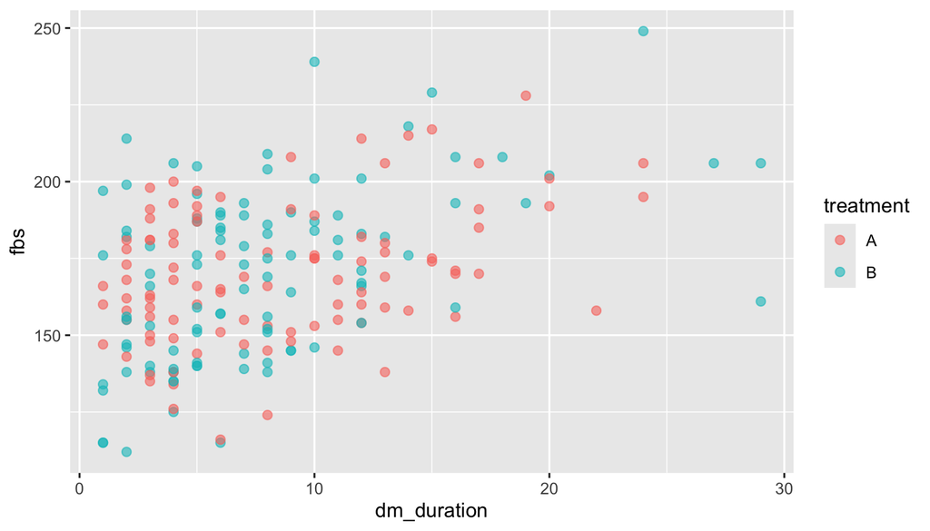

```r
p_scatter_arm <- ggplot2::ggplot(
  df_base,
  ggplot2::aes(x = dm_duration, y = fbs, colour = treatment)
) +
  ggplot2::geom_point(alpha = 0.6, size = 2)

p_scatter_arm
```

## 4.5 Step 5: a line plot

A line joins the points in the order of x. Each arm needs its own line, so the plot uses the summary table with one row per arm per month. The setting `group = treatment` says which points belong to the same line, and `colour = treatment` gives each line its own colour.

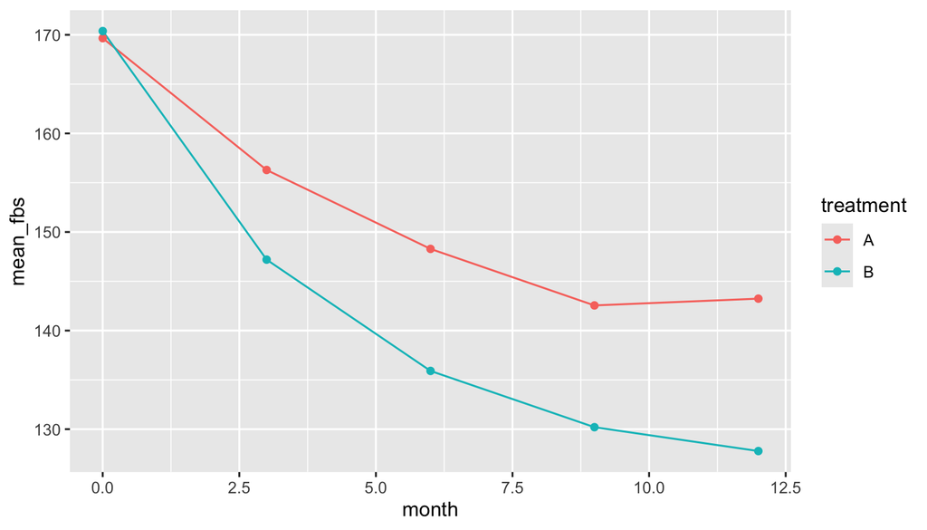

```r
p_line <- ggplot2::ggplot(
  df_mean,
  ggplot2::aes(x = month, y = mean_fbs, colour = treatment, group = treatment)
) +
  ggplot2::geom_line() +
  ggplot2::geom_point()

p_line
```

## 4.6 Step 6: a loess curve

`geom_smooth()` draws a fitted curve over the raw points. A loess curve is a flexible local fit. It follows the data without a shape chosen in advance, so it is a good first look. The grey band is the 95% confidence interval.

The x axis is `time_months`, the exact time of each visit, so the dots spread out instead of sitting in five columns.

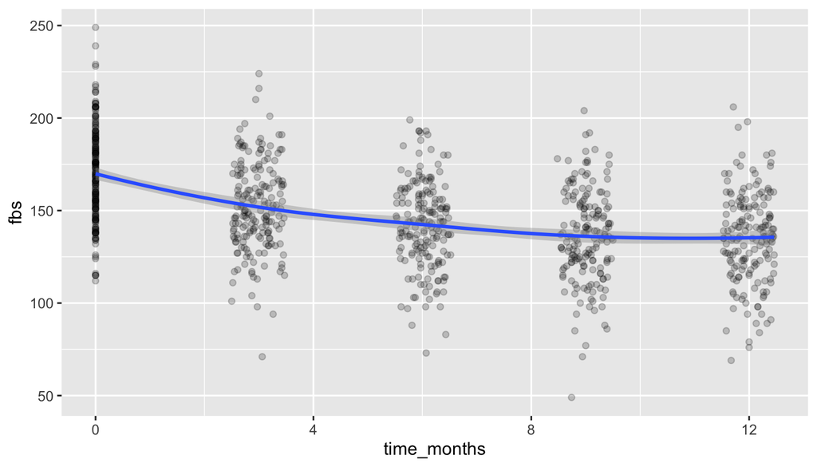

```r
p_loess <- ggplot2::ggplot(dfl, ggplot2::aes(x = time_months, y = fbs)) +
  ggplot2::geom_point(alpha = 0.2) +
  ggplot2::geom_smooth(method = "loess", formula = y ~ x)

p_loess
```

## 4.7 Step 7: a straight line, the linear fit

The setting `method = "lm"` fits a linear regression of y on x and draws it as a straight line. FBS falls fast at first and then levels off. A straight line cannot bend, so it misses that shape. Compare it with the loess curve of step 6.

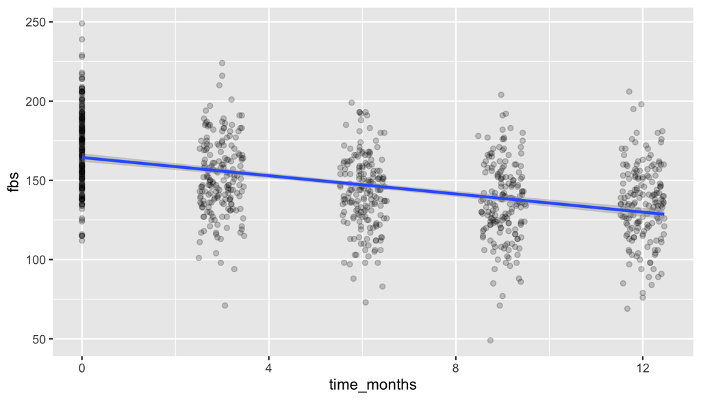

```r
p_linear <- ggplot2::ggplot(dfl, ggplot2::aes(x = time_months, y = fbs)) +
  ggplot2::geom_point(alpha = 0.2) +
  ggplot2::geom_smooth(method = "lm", formula = y ~ x)

p_linear
```

## 4.8 Step 8: curved fits, quadratic and cubic

The fit is still `method = "lm"`, but the formula now has a curve written into it. The term `poly(x, 2)` adds x squared, which makes a quadratic with one bend. The term `poly(x, 3)` adds x cubed as well, which makes a cubic with up to two bends.

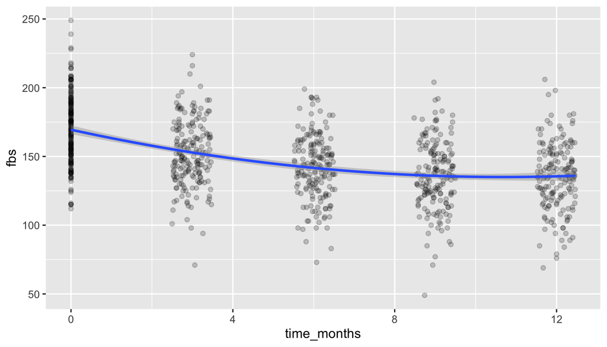

```r
p_quadratic <- ggplot2::ggplot(dfl, ggplot2::aes(x = time_months, y = fbs)) +
  ggplot2::geom_point(alpha = 0.2) +
  ggplot2::geom_smooth(method = "lm", formula = y ~ poly(x, 2))

p_cubic <- ggplot2::ggplot(dfl, ggplot2::aes(x = time_months, y = fbs)) +
  ggplot2::geom_point(alpha = 0.2) +
  ggplot2::geom_smooth(method = "lm", formula = y ~ poly(x, 3))

p_quadratic
```

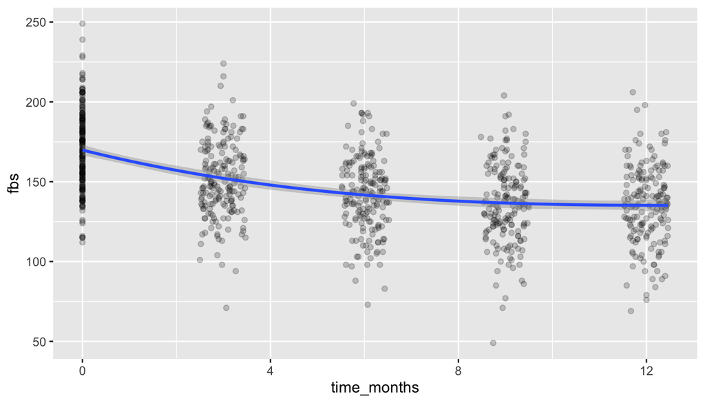

```r
p_cubic
```

## 4.9 Step 9: all four fits on one plot

Several `geom_smooth()` layers can share one plot. Writing `colour = "Linear"` inside `aes()` gives that line a name, so the legend lists every fit. The setting `se = FALSE` drops the confidence bands, which would hide each other here. The loess, quadratic and cubic curves follow the levelling off. The straight line does not.

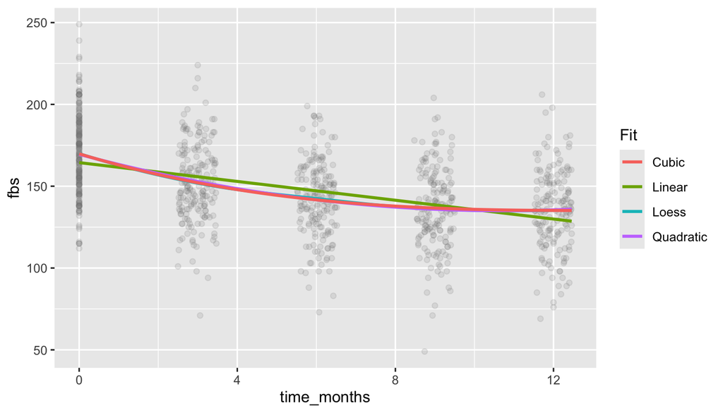

```r
p_fits <- ggplot2::ggplot(dfl, ggplot2::aes(x = time_months, y = fbs)) +
  ggplot2::geom_point(alpha = 0.15, colour = "grey50") +
  ggplot2::geom_smooth(
    ggplot2::aes(colour = "Loess"),
    method = "loess",
    formula = y ~ x,
    se = FALSE
  ) +
  ggplot2::geom_smooth(
    ggplot2::aes(colour = "Linear"),
    method = "lm",
    formula = y ~ x,
    se = FALSE
  ) +
  ggplot2::geom_smooth(
    ggplot2::aes(colour = "Quadratic"),
    method = "lm",
    formula = y ~ poly(x, 2),
    se = FALSE
  ) +
  ggplot2::geom_smooth(
    ggplot2::aes(colour = "Cubic"),
    method = "lm",
    formula = y ~ poly(x, 3),
    se = FALSE
  ) +
  ggplot2::labs(colour = "Fit")

p_fits
```

## 4.10 Step 10: bar graphs

There are two bar geoms. The function `geom_bar()` counts the rows for you, so it draws one bar per sex, with a height equal to the number of patients. The setting `fill` colours the inside of the bars, while `colour` is only the outline. The function `geom_col()` draws a height you already worked out, here the mean FBS. The call `factor(month)` makes month a set of groups, so each visit gets its own bars. The setting `position = "dodge"` puts the two arms side by side instead of stacking them.

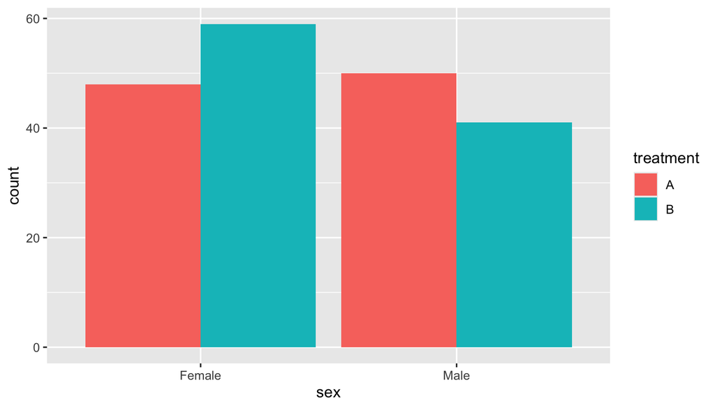

```r
p_bar_count <- df_base |>
  dplyr::filter(!is.na(sex)) |>
  ggplot2::ggplot(ggplot2::aes(x = sex, fill = treatment)) +
  ggplot2::geom_bar(position = "dodge")

p_bar_mean <- ggplot2::ggplot(
  df_mean,
  ggplot2::aes(x = factor(month), y = mean_fbs, fill = treatment)
) +
  ggplot2::geom_col(position = "dodge")

p_bar_count
```

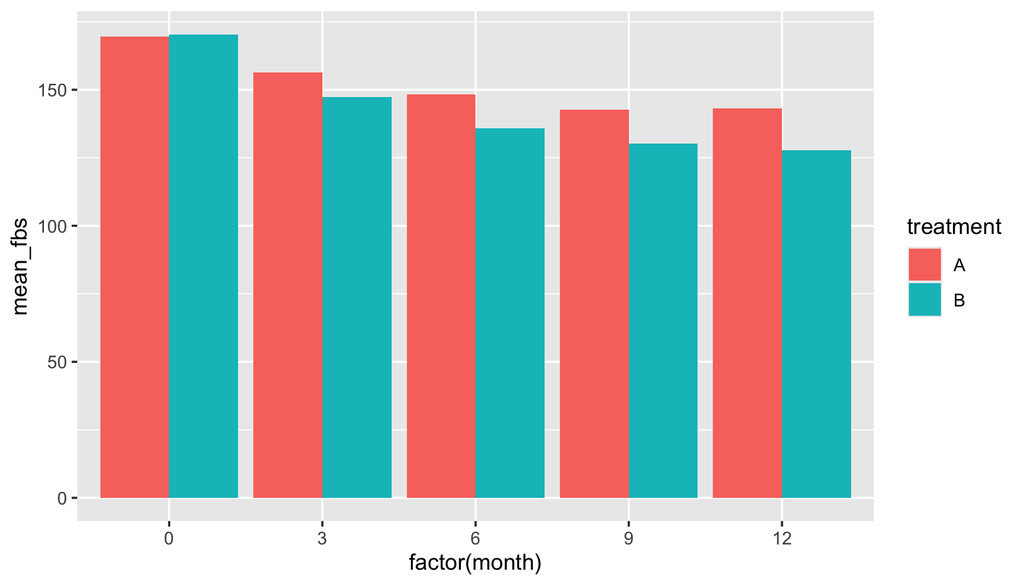

```r
p_bar_mean
```

## 4.11 Step 11: change the theme, theme_classic

A theme changes the look, never the data. The default is `theme_grey()`, which has a grey panel and a white grid. The function `theme_classic()` is the usual choice for a paper. It has a white background, an x and a y axis line with ticks, and no grid. A theme is added with `+` like any other layer. The complete themes `theme_bw()`, `theme_minimal()` and `theme_light()` are also worth a try.

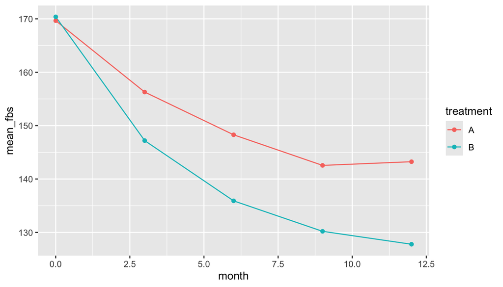

```r
p_grey    <- p_line
p_classic <- p_line + ggplot2::theme_classic()

p_grey
```

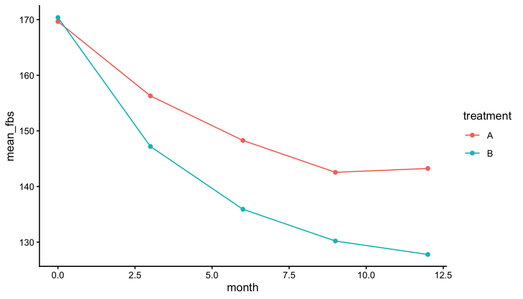

```r
p_classic
```

## 4.12 Step 12: add the axis lines and ticks yourself

`theme_minimal()` has no axis lines and no ticks, so it is a good place to learn how to add them. The element `axis.line` draws the x and y axis, `axis.ticks` draws the tick marks and `axis.ticks.length` sets how long the ticks are.

The scale sets where the ticks go. The `breaks` argument of `scale_x_continuous()` chooses where the ticks go, here at each visit. The `limits` argument sets the range of an axis. Here the y axis starts at 0, which shows the fall in FBS against its full size. The call `guide_axis(minor.ticks = TRUE)` adds small unlabelled ticks between the others.

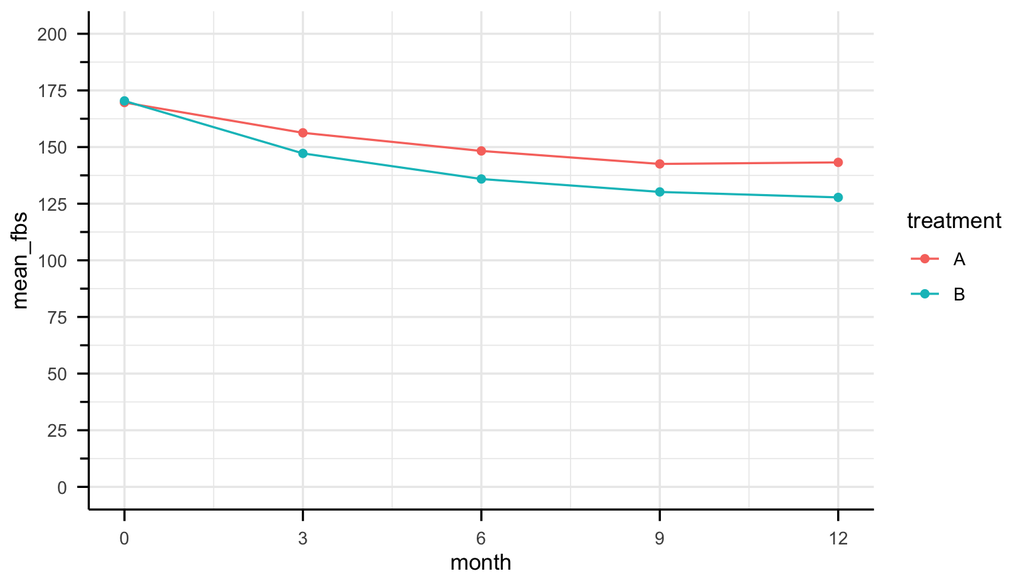

```r
p_axes <- p_line +
  ggplot2::theme_minimal() +
  ggplot2::theme(
    axis.line         = ggplot2::element_line(colour = "black"),
    axis.ticks        = ggplot2::element_line(colour = "black"),
    axis.ticks.length = ggplot2::unit(0.2, "cm")
  ) +
  ggplot2::scale_x_continuous(breaks = c(0, 3, 6, 9, 12)) +
  ggplot2::scale_y_continuous(limits = c(0, 200), breaks = seq(0, 200, by = 25)) +
  ggplot2::guides(y = ggplot2::guide_axis(minor.ticks = TRUE))

p_axes
```

## 4.13 Step 13: name the axes, the legend and the plot

`labs()` names everything in one place. It names the x and y axis, the legend, a title, a subtitle and a caption. The legend is named after the aesthetic it shows, here `colour`. The caption on this plot says Mock-up data.

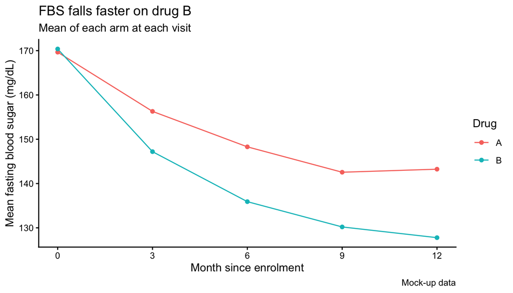

```r
p_named <- p_classic +
  ggplot2::scale_x_continuous(breaks = c(0, 3, 6, 9, 12)) +
  ggplot2::labs(
    x        = "Month since enrolment",
    y        = "Mean fasting blood sugar (mg/dL)",
    colour   = "Drug",
    title    = "FBS falls faster on drug B",
    subtitle = "Mean of each arm at each visit",
    caption  = "Mock-up data"
  )

p_named
```

## 4.14 Step 14: bold, size and face of the axis text and the title

`theme()` changes one piece of text at a time with `element_text()`. The element `axis.text` is the numbers on the axes and `axis.title` is the axis names. The element `plot.title` is the title, and `legend.title` and `legend.text` are the legend. The `face` argument can be plain, bold, italic or bold.italic, and `size` is in points. Add `.x` or `.y` to change one axis only, for example `axis.text.x`. The setting `hjust = 0.5` centres the title, where 0 is left and 1 is right.

Here bold also means a thicker axis line and thicker ticks, and never a thicker data line. The theme is kept in an object called `bold_text`, so it can be added to any later plot with one `+`.

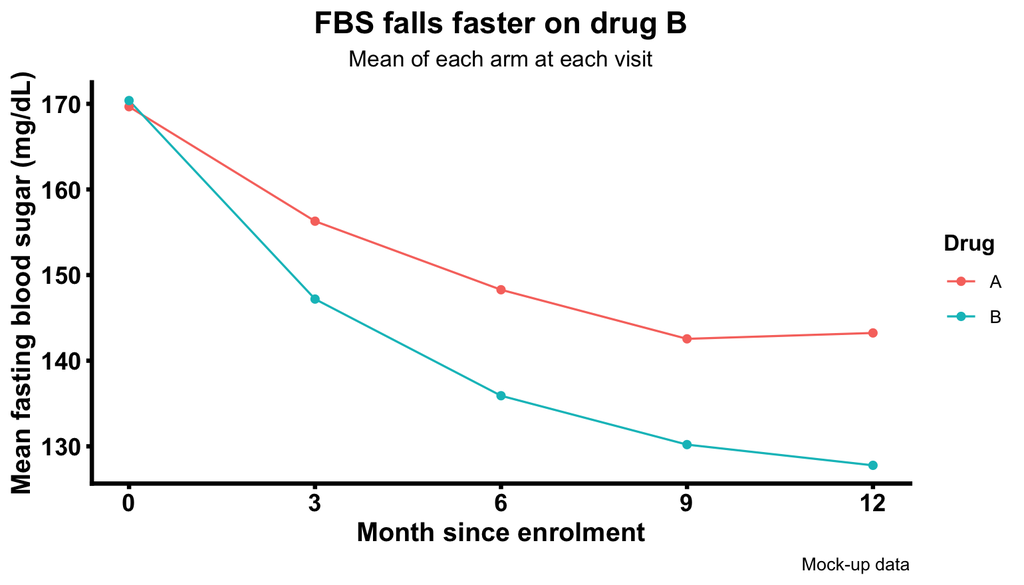

```r
bold_text <- ggplot2::theme(
  axis.text     = ggplot2::element_text(face = "bold", size = 12, colour = "black"),
  axis.title    = ggplot2::element_text(face = "bold", size = 13),
  plot.title    = ggplot2::element_text(face = "bold", size = 15, hjust = 0.5),
  plot.subtitle = ggplot2::element_text(hjust = 0.5),
  legend.title  = ggplot2::element_text(face = "bold"),
  axis.line     = ggplot2::element_line(linewidth = 1),
  axis.ticks    = ggplot2::element_line(linewidth = 1)
)

p_text <- p_named + bold_text

p_text
```

## 4.15 Step 15: dodge the points so the arms do not overlap

At each month the two arms sit at almost the same height, so their points and error bars cover each other. The error bars show the mean plus and minus one SD. The function `position_dodge()` moves each arm a little to the side. Give the same dodge to every layer that has to move together, namely the error bars, the lines and the points.

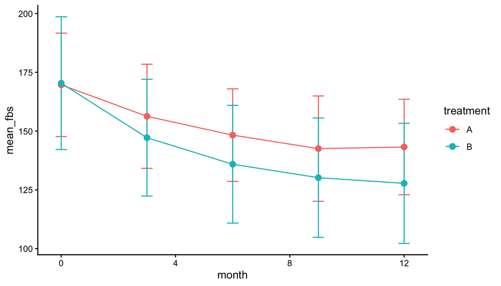

```r
p_overlap <- ggplot2::ggplot(
  df_mean,
  ggplot2::aes(x = month, y = mean_fbs, colour = treatment, group = treatment)
) +
  ggplot2::geom_errorbar(
    ggplot2::aes(ymin = mean_fbs - sd_fbs, ymax = mean_fbs + sd_fbs),
    width = 0.4
  ) +
  ggplot2::geom_line() +
  ggplot2::geom_point(size = 2.5) +
  ggplot2::theme_classic()

dodge <- ggplot2::position_dodge(width = 0.8)

p_dodged <- ggplot2::ggplot(
  df_mean,
  ggplot2::aes(x = month, y = mean_fbs, colour = treatment, group = treatment)
) +
  ggplot2::geom_errorbar(
    ggplot2::aes(ymin = mean_fbs - sd_fbs, ymax = mean_fbs + sd_fbs),
    width = 0.4,
    position = dodge
  ) +
  ggplot2::geom_line(position = dodge) +
  ggplot2::geom_point(size = 2.5, position = dodge) +
  ggplot2::scale_x_continuous(breaks = c(0, 3, 6, 9, 12)) +
  ggplot2::labs(
    x = "Month since enrolment",
    y = "Fasting blood sugar (mg/dL), mean (SD)",
    colour = "Drug"
  ) +
  ggplot2::theme_classic() +
  bold_text

p_overlap
```

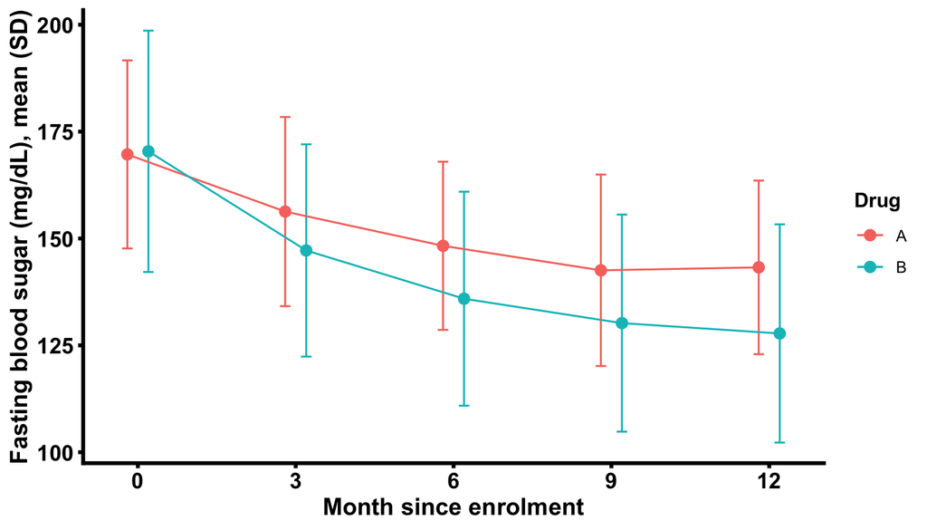

```r
p_dodged
```

## 4.16 Step 16: dodge the raw points too

With one dot per patient, the dots of the two arms also land on top of each other. The function `position_jitterdodge()` first puts the arms side by side, which is the dodge. It then spreads the dots of each arm a little sideways, which is the jitter. Now every patient can be seen. The call `factor(month)` makes each visit a group to dodge within.

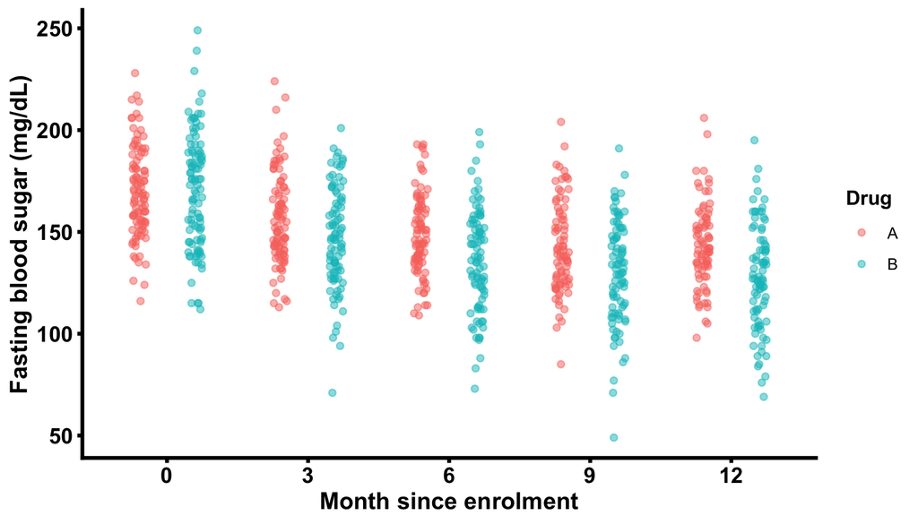

```r
p_raw_dodged <- ggplot2::ggplot(
  dfl,
  ggplot2::aes(x = factor(month), y = fbs, colour = treatment)
) +
  ggplot2::geom_point(
    alpha = 0.5,
    position = ggplot2::position_jitterdodge(
      jitter.width = 0.2,
      dodge.width = 0.8,
      seed = 123
    )
  ) +
  ggplot2::labs(
    x = "Month since enrolment",
    y = "Fasting blood sugar (mg/dL)",
    colour = "Drug"
  ) +
  ggplot2::theme_classic() +
  bold_text

p_raw_dodged
```

## 4.17 Step 17: save the finished figure

```r
dir.create("output/figures", showWarnings = FALSE)

ggplot2::ggsave(
  path_fig,
  p_dodged,
  device = ragg::agg_tiff,
  width = 7,
  height = 4.5,
  units = "in",
  dpi = 300,
  compression = "lzw"
)
```

## 4.18 Step 18: check

The check stops the script if something is off. It expects one mean per arm at each of the five visits, which is 10 rows. It also expects the finished figure to exist on disk.

```r
stopifnot(
  nrow(df_mean) == 2 * 5,
  file.exists(path_fig)
)
```

# 5 Propensity score: the model and the weights

| **Script** | `code/5_ps_model.r` |
| --- | --- |
| **In** | `data/fbs_mockup_cohort.xlsx`, one row per patient |
| **Out** | `output/ps_cohort.rds`, the cohort with the propensity score, the weight and common support |
| **How to run** | Step by step. Each step adds a column to `df`. |

This chapter leaves the trial. A propensity score answers a question about patients who were **not** randomised, so it needs a different data set. The cohort is a mock-up made for teaching. No real patient is involved.

## 5.1 The question and the cohort

| **Question** | Does drug B lower FBS at month 6 more than drug A? |
| --- | --- |
| **Design** | Retrospective cohort. The doctor chose the drug. |
| **Patients** | 600, one row each. Drug A 346, drug B 254. |
| **Outcome** | `fbs_m6`, fasting blood sugar at month 6 (mg/dL) |
| **Confounders** | Age, sex, BMI, diabetes duration, FBS at month 0 |

The doctor chose drug B more often for patients whose diabetes looked worse. So the two groups differ before the drug is even started. This is confounding by indication. A plain comparison of month 6 FBS mixes the effect of the drug with the effect of who got it.

```
flowchart LR
  C["Confounders<br/>age, sex, BMI,<br/>DM duration, FBS month 0"] --> T["Drug<br/>A or B"]
  C --> Y["FBS<br/>month 6"]
  T --> Y
```

The propensity score (PS) is each patient’s probability of getting drug B, given the confounders. Patients with the same PS are comparable, whichever drug they actually got.

| Script | Job |
| --- | --- |
| 5 (this chapter) | Build the PS, the weights and common support |
| 6 (next chapter) | Check that the weights balance the confounders |
| 7 | Estimate the effect of drug B |

## 5.2 Step 1: packages and paths

| Package | Its one job here |
| --- | --- |
| readxl (Wickham and Bryan 2026) | Read the Excel sheet |
| dplyr (Wickham, François, et al. 2026) | The verbs |
| ggplot2 (Wickham, Chang, et al. 2026) | The overlap histogram |

```r
library(readxl)
library(dplyr)
library(ggplot2)

path_raw <- "data/fbs_mockup_cohort.xlsx"
path_ps  <- "output/ps_cohort.rds"
```

## 5.3 Step 2: import

This sheet is already clean, so the types are set straight away. Drug A is the first level of `treatment`, so the model in step 3 gives the probability of drug B.

```r
df <- readxl::read_excel(path_raw, sheet = "data") |>
  dplyr::mutate(
    treatment = factor(treatment, levels = c("A", "B")),
    sex = factor(sex, levels = c("Female", "Male"))
  )
```

| id | treatment | age | sex | bmi | dm_duration | fbs_m0 | fbs_m6 |
| --- | --- | --- | --- | --- | --- | --- | --- |
| 1 | A | 55 | Male | 31.6 | 5 | 110 | 93 |
| 2 | B | 53 | Male | 27.5 | 21 | 162 | 106 |
| 3 | A | 75 | Female | 29.5 | 4 | 163 | 107 |
| 4 | A | 60 | Male | 26.0 | 6 | 151 | 134 |
| 5 | B | 49 | Female | 21.6 | 8 | 258 | 168 |
| 6 | B | 54 | Male | 27.7 | 4 | 216 | 136 |

## 5.4 Step 3: the propensity score model

A logistic regression of the drug on the confounders.

| Goes into the PS model | Stays out |
| --- | --- |
| Variables that made the doctor choose B **and** change FBS at month 6 | The outcome, `fbs_m6` |
| Age, sex, BMI, diabetes duration, FBS at month 0 | Anything measured after the drug was started |

The PS describes who got which drug, not what happened afterwards. So the outcome is never in this model.

```r
ps_model <- glm(
  treatment ~ age + sex + bmi + dm_duration + fbs_m0,
  family = binomial(link = "logit"),
  data = df
)

summary(ps_model)
```

```
#>
#> Call:
#> glm(formula = treatment ~ age + sex + bmi + dm_duration + fbs_m0,
#>     family = binomial(link = "logit"), data = df)
#>
#> Coefficients:
#>             Estimate Std. Error z value Pr(>|z|)
#> (Intercept) -5.85729    1.04636  -5.598 2.17e-08 ***
#> age         -0.01822    0.01015  -1.795 0.072708 .
#> sexMale      0.31596    0.18040   1.751 0.079867 .
#> bmi          0.08644    0.02306   3.748 0.000178 ***
#> dm_duration  0.05757    0.01528   3.766 0.000166 ***
#> fbs_m0       0.02126    0.00317   6.709 1.96e-11 ***
#> ---
#> Signif. codes:  0 '***' 0.001 '**' 0.01 '*' 0.05 '.' 0.1 ' ' 1
#>
#> (Dispersion parameter for binomial family taken to be 1)
#>
#>     Null deviance: 817.61  on 599  degrees of freedom
#> Residual deviance: 728.64  on 594  degrees of freedom
#> AIC: 740.64
#>
#> Number of Fisher Scoring iterations: 4
```

## 5.5 Step 4: each patient’s propensity score

`predict()` with `type = "response"` gives a probability between 0 and 1. Without it, `predict()` gives the log odds.

```r
df <- df |>
  dplyr::mutate(ps = predict(ps_model, type = "response"))
```

| id | treatment | age | fbs_m0 | ps |
| --- | --- | --- | --- | --- |
| 1 | A | 55 | 110 | 0.2341498 |
| 2 | B | 53 | 162 | 0.6280405 |
| 3 | A | 75 | 163 | 0.2733924 |
| 4 | A | 60 | 151 | 0.3034777 |
| 5 | B | 49 | 258 | 0.7434108 |
| 6 | B | 54 | 216 | 0.6665321 |

## 5.6 Step 5: the weights, ATE

Inverse probability of treatment weighting (IPTW). Each patient is weighted by the probability of the drug they **actually** got.

| Patient got | Weight | Example |
| --- | --- | --- |
| Drug B | $1 / \text{PS}$ | PS = 0.2, so the weight is 5 |
| Drug A | $1 / (1 - \text{PS})$ | PS = 0.2, so the weight is 1.25 |

A patient on drug B with a PS of 0.2 was unusual for B, so stands in for 5 patients. A patient on drug A with the same PS was typical for A, so stands in for little more than one.

This weight answers the average treatment effect (ATE), namely everyone on drug B compared with everyone on drug A.

```r
df <- df |>
  dplyr::mutate(
    weight = dplyr::case_when(
      treatment == "B" ~ 1 / ps,
      treatment == "A" ~ 1 / (1 - ps)
    )
  )

summary(df$weight)
```

```
#>    Min. 1st Qu.  Median    Mean 3rd Qu.    Max.
#>   1.050   1.386   1.672   1.992   2.267   7.921
```

## 5.7 Step 6: overlap, the PS of each group

| What to look for | Why |
| --- | --- |
| Drug B sits to the right of drug A | Confounding by indication. B went to the sicker patients. |
| The two histograms still overlap | Where only one group exists, nobody can be compared. This is the positivity assumption. |

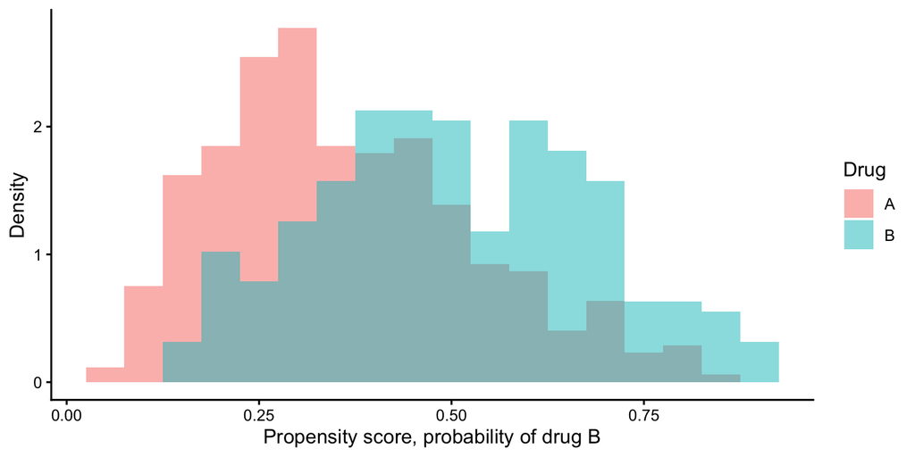

```r
p_overlap <- ggplot2::ggplot(
  df,
  ggplot2::aes(x = ps, fill = treatment)
) +
  ggplot2::geom_histogram(
    ggplot2::aes(y = ggplot2::after_stat(density)),
    binwidth = 0.05,
    alpha = 0.5,
    position = "identity"
  ) +
  ggplot2::labs(
    x = "Propensity score, probability of drug B",
    y = "Density",
    fill = "Drug"
  ) +
  ggplot2::theme_classic()

p_overlap
```

## 5.8 Step 7: common support

Common support is the PS range where both groups have patients. It runs from the larger of the two minimums to the smaller of the two maximums.

```r
ps_range <- df |>
  dplyr::summarise(
    ps_min = min(ps),
    ps_max = max(ps),
    .by = treatment
  )

ps_range
```

```
#> # A tibble: 2 × 3
#>   treatment ps_min ps_max
#>   <fct>      <dbl>  <dbl>
#> 1 A         0.0478  0.874
#> 2 B         0.138   0.910
```

```r
cs_low <- max(ps_range$ps_min)
cs_high <- min(ps_range$ps_max)

df <- df |>
  dplyr::mutate(comsup = dplyr::between(ps, cs_low, cs_high))

off_support <- df |>
  dplyr::filter(!comsup) |>
  dplyr::select(id, treatment, ps)

off_support
```

```
#> # A tibble: 26 × 3
#>       id treatment     ps
#>    <dbl> <fct>      <dbl>
#>  1    18 A         0.112
#>  2    80 A         0.121
#>  3   180 A         0.0617
#>  4   189 A         0.135
#>  5   198 B         0.886
#>  6   201 A         0.127
#>  7   217 A         0.121
#>  8   258 A         0.100
#>  9   292 A         0.0771
#> 10   303 A         0.101
#> # ℹ 16 more rows
```

Common support runs from 0.14 to 0.87. 26 patients fall outside it, and they stay in `off_support` to look at. The column `comsup` marks each patient, so a later analysis can keep only those inside.

## 5.9 Step 8: check and save

The checks repeat what is already known. 600 patients, every PS strictly between 0 and 1, and every weight at least 1.

```r
stopifnot(
  nrow(df) == 600,
  all(df$ps > 0 & df$ps < 1),
  all(df$weight >= 1)
)

saveRDS(df, path_ps)
```

# 6 Propensity score: is the weighted cohort balanced?

| **Script** | `code/6_ps_balance.r` |
| --- | --- |
| **In** | `output/ps_cohort.rds`, from chapter 5 |
| **Out** | `output/ps_balance.rds`, the cobalt balance table |
| **How to run** | Step by step, after script 5 |

The weights from chapter 5 are meant to make drug A and drug B look alike on the confounders, as if the drug had been given at random. This chapter checks whether they did. If the groups are still unbalanced after weighting, the effect in script 7 is still confounded. So this check comes first.

## 6.1 The yardstick, the standardised mean difference

$$\text{SMD} = \frac{\bar{x}_B - \bar{x}_A}{\sqrt{(s_A^2 + s_B^2) / 2}}$$

|  | SMD | p-value |
| --- | --- | --- |
| **Measures** | The size of the gap, in SD units | Whether the gap could be chance |
| **Depends on sample size** | No | Yes. A big cohort makes a tiny gap “significant”. |
| **Balanced when** | Absolute SMD below 0.1 | Not used for balance |

The sign only says which drug has the higher mean. Read the size.

## 6.2 Step 1: packages and paths

| Package | Its one job here |
| --- | --- |
| dplyr (Wickham, François, et al. 2026) | The verbs |
| ggplot2 (Wickham, Chang, et al. 2026) | `theme_classic()` on the cobalt plots |
| cobalt (Greifer 2026) | `bal.tab()`, `love.plot()` and `bal.plot()`, balance for PS work |
| gtsummary (Sjoberg et al. 2026) | Table 1 with an SMD column |
| survey (Gao, Schneider, and Kolenkikov 2026) | `svydesign()`, the weighted cohort for the weighted Table 1 |

```r
library(dplyr)
library(ggplot2)
library(cobalt)
library(gtsummary)
library(survey)

path_ps      <- "output/ps_cohort.rds"
path_balance <- "output/ps_balance.rds"
```

## 6.3 Step 2: import

```r
df <- readRDS(path_ps)
```

## 6.4 Step 3: SMD before and after weighting

The formula holds the same five confounders that went into the PS model.

| Argument | What it does |
| --- | --- |
| `weights = "weight"` | The IPTW weight from chapter 5 |
| `estimand = "ATE"` | The weights target everyone, as in chapter 5 |
| `un = TRUE` | Adds the column before weighting (`Diff.Un`) beside the column after (`Diff.Adj`) |
| `s.d.denom = "pooled"` | Divides by the pooled SD of the two drugs |
| `binary = "std"` | Gives sex an SMD too, not a raw difference in proportions |
| `thresholds = c(m = 0.1)` | Adds a column that says Balanced or Not Balanced |

cobalt takes B minus A. A positive SMD means drug B has the higher mean.

```r
bal <- cobalt::bal.tab(
  treatment ~ age + sex + bmi + dm_duration + fbs_m0,
  data = df,
  weights = "weight",
  estimand = "ATE",
  s.d.denom = "pooled",
  binary = "std",
  continuous = "std",
  un = TRUE,
  thresholds = c(m = 0.1)
)

bal
```

```
#> Balance Measures
#>                Type Diff.Un Diff.Adj    M.Threshold
#> age         Contin. -0.1099   0.0225 Balanced, <0.1
#> sex_Male     Binary  0.1489  -0.0093 Balanced, <0.1
#> bmi         Contin.  0.2985  -0.0198 Balanced, <0.1
#> dm_duration Contin.  0.3573   0.0205 Balanced, <0.1
#> fbs_m0      Contin.  0.6217   0.0424 Balanced, <0.1
#>
#> Balance tally for mean differences
#>                    count
#> Balanced, <0.1         5
#> Not Balanced, >0.1     0
#>
#> Variable with the greatest mean difference
#>  Variable Diff.Adj    M.Threshold
#>    fbs_m0   0.0424 Balanced, <0.1
#>
#> Effective sample sizes
#>                 A      B
#> Unadjusted 346.   254.
#> Adjusted   290.64 208.65
```

```r
still_unbalanced <- bal$Balance |>
  tibble::rownames_to_column("variable") |>
  dplyr::filter(abs(Diff.Adj) >= 0.1)

still_unbalanced
```

```
#> [1] variable    Type        Diff.Un     Diff.Adj    M.Threshold
#> <0 rows> (or 0-length row.names)
```

Before weighting, the largest gap is FBS at month 0, SMD 0.62. After weighting, every absolute SMD is below 0.05. `still_unbalanced` keeps any confounder at 0.1 or above, and it has 0 rows.

## 6.5 Step 4: love plot

One dot per confounder, before weighting (Unadjusted) and after (Adjusted). Every Adjusted dot should sit left of the dashed line at 0.1.

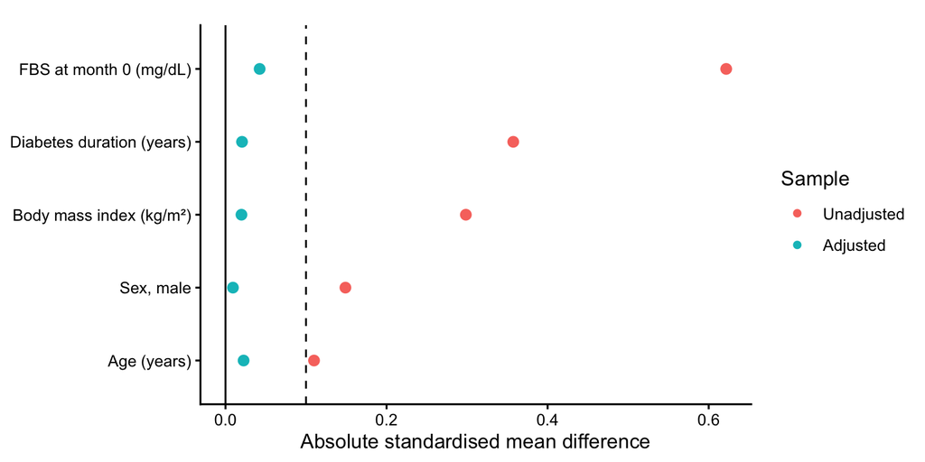

```r
p_love <- cobalt::love.plot(
  bal,
  abs = TRUE,
  thresholds = c(m = 0.1),
  var.order = "unadjusted",
  var.names = c(
    age = "Age (years)",
    sex_Male = "Sex, male",
    bmi = "Body mass index (kg/m²)",
    dm_duration = "Diabetes duration (years)",
    fbs_m0 = "FBS at month 0 (mg/dL)"
  ),
  title = NULL
) +
  ggplot2::labs(x = "Absolute standardised mean difference") +
  ggplot2::theme_classic()

p_love
```

## 6.6 Step 5: mirror histogram, the PS before and after weighting

Drug A on top, drug B below. The left panel is the raw cohort. The right panel is the weighted cohort, the pseudo-population. After weighting, the two halves should look like mirror images.

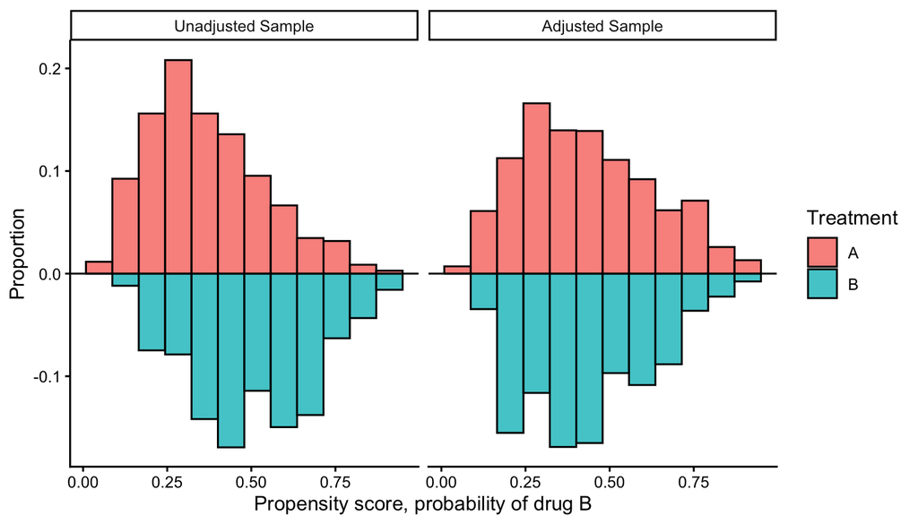

```r
p_mirror <- cobalt::bal.plot(
  treatment ~ ps,
  data = df,
  weights = "weight",
  var.name = "ps",
  which = "both",
  type = "histogram",
  mirror = TRUE
) +
  ggplot2::labs(
    title = NULL,
    x = "Propensity score, probability of drug B"
  ) +
  ggplot2::theme_classic()

p_mirror
```

## 6.7 Step 6: effective sample size

Large weights mean a few patients stand in for many. The weighted cohort then carries less information than its row count. The effective sample size (ESS) says how many unweighted patients it is worth.

```r
bal$Observations
```

```
#>                   A        B
#> Unadjusted 346.0000 254.0000
#> Adjusted   290.6413 208.6475
```

| Drug | Patients | ESS | Kept |
| --- | --- | --- | --- |
| A | 346 | 291 | 84% |
| B | 254 | 209 | 82% |

A big drop from the number of patients warns that the estimate in script 7 will be imprecise.

## 6.8 Step 7: Table 1 with SMD, before and after weighting

The same Table 1 twice, side by side. `add_difference()` with `"smd"` adds one SMD per row. There are no p values, because the question is the size of the gap, not chance.

|  | Before weighting | After weighting |
| --- | --- | --- |
| **Built with** | `tbl_summary()` on `df` | `tbl_svysummary()` on `df_svy` |
| **N in the header** | Patients | Sum of the weights, the pseudo-population |
| **SMD sign** | A minus B, the opposite of cobalt | A minus B |

`svydesign()` tells gtsummary that each row counts as `weight` patients. `modify_column_hide()` drops the CI of the SMD, which nobody reads here. `tbl_merge()` puts the two tables side by side.

```r
tbl_raw <- df |>
  gtsummary::tbl_summary(
    include = c(age, sex, bmi, dm_duration, fbs_m0),
    by = treatment,
    label = list(
      age ~ "Age (years)",
      sex ~ "Sex",
      bmi ~ "Body mass index (kg/m²)",
      dm_duration ~ "Diabetes duration (years)",
      fbs_m0 ~ "FBS at month 0 (mg/dL)"
    ),
    statistic = list(
      c(age, bmi, fbs_m0) ~ "{mean} ({sd})",
      dm_duration ~ "{median} ({p25}, {p75})"
    )
  ) |>
  gtsummary::add_difference(everything() ~ "smd") |>
  gtsummary::modify_header(estimate = "**SMD**") |>
  gtsummary::modify_column_hide(conf.low)

df_svy <- survey::svydesign(
  ids = ~1,
  weights = ~weight,
  data = df
)

tbl_wt <- df_svy |>
  gtsummary::tbl_svysummary(
    include = c(age, sex, bmi, dm_duration, fbs_m0),
    by = treatment,
    label = list(
      age ~ "Age (years)",
      sex ~ "Sex",
      bmi ~ "Body mass index (kg/m²)",
      dm_duration ~ "Diabetes duration (years)",
      fbs_m0 ~ "FBS at month 0 (mg/dL)"
    ),
    statistic = list(
      c(age, bmi, fbs_m0) ~ "{mean} ({sd})",
      dm_duration ~ "{median} ({p25}, {p75})"
    )
  ) |>
  gtsummary::add_difference(everything() ~ "smd") |>
  gtsummary::modify_header(estimate = "**SMD**") |>
  gtsummary::modify_column_hide(conf.low)

tbl_ps <- gtsummary::tbl_merge(
  list(tbl_raw, tbl_wt),
  tab_spanner = c("**Before weighting**", "**After weighting**")
)

tbl_ps
```

| **Characteristic** | **Before weighting** **A** N = 346<sup>1</sup> | **Before weighting** **B** N = 254<sup>1</sup> | **Before weighting** **SMD**<sup>2</sup> | **After weighting** **A** N = 605<sup>1</sup> | **After weighting** **B** N = 590<sup>1</sup> | **After weighting** **SMD**<sup>2</sup> |
| --- | --- | --- | --- | --- | --- | --- |
| Age (years) | 59 (9) | 58 (9) | 0.11 | 58 (9) | 59 (9) | -0.02 |
| Sex |  |  | 0.15 |  |  | 0.01 |
| Female | 204 (59%) | 131 (52%) |  | 343 (57%) | 337 (57%) |  |
| Male | 142 (41%) | 123 (48%) |  | 262 (43%) | 253 (43%) |  |
| Body mass index (kg/m²) | 26.6 (4.0) | 27.8 (3.9) | -0.30 | 27.2 (4.2) | 27.2 (3.9) | 0.02 |
| Diabetes duration (years) | 6.0 (3.0, 10.0) | 8.0 (5.0, 12.0) | -0.36 | 7.0 (4.0, 11.0) | 6.0 (4.0, 11.0) | -0.02 |
| FBS at month 0 (mg/dL) | 163 (30) | 181 (28) | -0.62 | 171 (32) | 172 (28) | -0.04 |

<sup>1</sup> Mean (SD); n (%); Median (Q1, Q3)  
<sup>2</sup> Standardized Mean Difference  
Abbreviation: CI = Confidence Interval

## 6.9 Step 8: check and save

```r
stopifnot(
  nrow(df) == 600,
  nrow(bal$Balance) == 5
)

saveRDS(bal, path_balance)
```

# 7 Propensity score: the effect of drug B

| **Script** | `code/7_ps_effect.r` |
| --- | --- |
| **In** | `output/ps_cohort.rds`, from chapter 5 |
| **Out** | `output/ps_effect.rds`, one row per method with B minus A, the 95% CI and the p value |
| **How to run** | Step by step, after scripts 5 and 6 |

Chapter 6 showed that the weights balance the confounders. Now the effect itself. Six methods answer the same question, and every one ends with the same kind of number, a marginal effect.

The data are a mock-up, so the truth is known. Drug B lowers FBS at month 6 by **15 mg/dL** compared with drug A.

## 7.1 Marginal and conditional effects

|  | Conditional effect | Marginal effect |
| --- | --- | --- |
| **Answers** | For a patient with these covariates, how much does B change FBS? | If everyone got B instead of A, how much would the average FBS change? |
| **Comes from** | A model coefficient | emmeans, averaged over every patient |
| **Matches** | The model | The average treatment effect (ATE), the target of the weights in chapter 5 |

The two agree in a linear model with no interaction, as in steps 4 and 5. They differ once the drug effect varies across patients (step 6) or the model is not linear, such as logistic regression. The marginal effect is the one that answers the clinical question, so every method reports it.

emmeans gets it by counterfactual prediction. Every patient is predicted twice.

```
flowchart LR
  D["600 patients<br/>as they are"] --> A["Everyone set to drug A<br/>predict FBS month 6"]
  D --> B["Everyone set to drug B<br/>predict FBS month 6"]
  A --> MA["Average = mean FBS<br/>if all got A"]
  B --> MB["Average = mean FBS<br/>if all got B"]
  MA --> E["B minus A<br/>the marginal effect"]
  MB --> E
```

## 7.2 Step 1: packages and paths

| Package | Its one job here |
| --- | --- |
| dplyr (Wickham, François, et al. 2026) | The verbs |
| ggplot2 (Wickham, Chang, et al. 2026) | The forest plot |
| emmeans (Lenth and Piaskowski 2026) | `emmeans()` and `contrast()`, the marginal effect |
| survey (Gao, Schneider, and Kolenkikov 2026) | `svydesign()` and `svyglm()`, the weighted model with a robust SE |
| MatchIt (Ho et al. 2025) | `matchit()`, propensity score matching |
| optmatch (Hansen et al. 2024) | Does the full matching for MatchIt. Installed, not loaded. |
| sandwich (Zeileis and Lumley 2026) | `vcovCL()`, an SE that respects the matched sets |
| broom (Robinson et al. 2026) | `tidy()`, each contrast as one row |
| forcats (Wickham 2025a) | `fct_inorder()`, the methods in table order in the plot |

`truth` holds the true effect, −15 mg/dL, for the plot and the checks.

```r
library(dplyr)
library(ggplot2)
library(emmeans)
library(survey)
library(MatchIt)
library(sandwich)
library(broom)
library(forcats)

path_ps     <- "output/ps_cohort.rds"
path_effect <- "output/ps_effect.rds"

truth <- -15
```

## 7.3 Step 2: import

The PS methods in steps 5 to 8 use only the patients inside common support, from chapter 5.

```r
df <- readRDS(path_ps)

df_cs <- df |>
  dplyr::filter(comsup)
```

That leaves 574 of 600 patients in `df_cs`.

## 7.4 Step 3: crude, no adjustment

The plain difference in mean FBS at month 6. `method = "revpairwise"` takes the second level minus the first, so B minus A.

```r
fit_crude <- lm(
  fbs_m6 ~ treatment,
  data = df
)

emm_crude <- emmeans::emmeans(
  fit_crude,
  specs = ~ treatment
)

con_crude <- emmeans::contrast(
  emm_crude,
  method = "revpairwise"
)

con_crude
```

```
#>  contrast estimate   SE  df t.ratio p.value
#>  B - A       -1.59 1.92 598  -0.829  0.4072
```

The crude difference is only -1.6 mg/dL. Drug B went to the patients with higher FBS at month 0, and that hides most of its effect.

## 7.5 Step 4: multivariable regression

The outcome model adjusts for the five confounders directly, with no PS. `counterfactual = "treatment"` makes emmeans predict every patient on drug A and on drug B.

```r
fit_multi <- lm(
  fbs_m6 ~ treatment + age + sex + bmi + dm_duration + fbs_m0,
  data = df
)

emm_multi <- emmeans::emmeans(
  fit_multi,
  specs = ~ treatment,
  counterfactual = "treatment"
)

emm_multi
```

```
#>  treatment emmean    SE  df lower.CL upper.CL
#>  A            145 0.815 593      143      147
#>  B            130 0.963 593      128      132
#>
#> Results are averaged over the levels of: actual_treatment
#> Confidence level used: 0.95
```

```r
con_multi <- emmeans::contrast(
  emm_multi,
  method = "revpairwise"
)

con_multi
```

```
#>  contrast estimate   SE  df t.ratio p.value
#>  B - A         -15 1.31 593 -11.501 <0.0001
#>
#> Results are averaged over the levels of: actual_treatment
```

| emmeans output | Means |
| --- | --- |
| `A 145` | Mean FBS at month 6 if all 600 patients had got drug A |
| `B 130` | Mean FBS at month 6 if all 600 patients had got drug B |
| “averaged over the levels of: actual_treatment” | The average runs over every patient, whichever drug they actually got |
| `B - A` | The marginal effect, -15 mg/dL |

## 7.6 Step 5: PS as a covariate

One number, the PS, stands in for all five confounders.

```r
fit_pscov <- lm(
  fbs_m6 ~ treatment + ps,
  data = df_cs
)

emm_pscov <- emmeans::emmeans(
  fit_pscov,
  specs = ~ treatment,
  counterfactual = "treatment"
)

con_pscov <- emmeans::contrast(
  emm_pscov,
  method = "revpairwise"
)

con_pscov
```

```
#>  contrast estimate   SE  df t.ratio p.value
#>  B - A       -15.1 1.46 571 -10.326 <0.0001
#>
#> Results are averaged over the levels of: actual_treatment
```

## 7.7 Step 6: PS strata

| **Strata** | `ntile(ps, 5)` cuts the PS into five groups of equal size (quintiles) |
| --- | --- |
| **Inside one stratum** | A and B patients have similar PS, so they are comparable |
| **The model** | `treatment * ps_strata` gives a separate B minus A in each stratum |
| **The coefficient of drug B** | The effect in stratum 1 only, a conditional effect |
| **The marginal effect** | The five stratum effects averaged over all patients |

This is where the marginal effect matters most. Reading the coefficient would report stratum 1 and ignore the other four.

```r
df_cs <- df_cs |>
  dplyr::mutate(ps_strata = factor(dplyr::ntile(ps, 5)))

fit_strata <- lm(
  fbs_m6 ~ treatment * ps_strata,
  data = df_cs
)

emm_strata <- emmeans::emmeans(
  fit_strata,
  specs = ~ treatment,
  counterfactual = "treatment"
)
```

```
#> NOTE: Results may be misleading due to involvement in interactions
```

```r
con_strata <- emmeans::contrast(
  emm_strata,
  method = "revpairwise"
)

con_strata
```

```
#>  contrast estimate   SE  df t.ratio p.value
#>  B - A       -14.6 1.56 564  -9.382 <0.0001
#>
#> Results are averaged over the levels of: actual_treatment
```

## 7.8 Step 7: IPTW

The weight from chapter 5 builds the pseudo-population. `svyglm()` gives a robust (sandwich) SE, because the weights are not real patient counts. The model holds only the drug, so no counterfactual is needed. The two emmeans are already the weighted mean FBS of the pseudo-population.

```r
design_iptw <- survey::svydesign(
  ids = ~1,
  weights = ~weight,
  data = df_cs
)

fit_iptw <- survey::svyglm(
  fbs_m6 ~ treatment,
  design = design_iptw,
  family = gaussian(link = "identity")
)

emm_iptw <- emmeans::emmeans(
  fit_iptw,
  specs = ~ treatment
)

con_iptw <- emmeans::contrast(
  emm_iptw,
  method = "revpairwise"
)

con_iptw
```

```
#>  contrast estimate   SE  df t.ratio p.value
#>  B - A       -16.4 2.24 572  -7.323 <0.0001
```

## 7.9 Step 8: PS full matching

| **`method = "full"`** | Every patient goes into a matched set with at least one A and one B of similar PS. Nobody is thrown away. |
| --- | --- |
| **`estimand = "ATE"`** | The same target as the other methods |
| **`match.data()`** | Returns the cohort plus `weights`, the matching weight, and `subclass`, the matched set |
| **`vcovCL(cluster = ~subclass)`** | Patients in one matched set are not independent, so the SE is clustered by set |

```r
match_full <- MatchIt::matchit(
  treatment ~ age + sex + bmi + dm_duration + fbs_m0,
  data = df_cs,
  method = "full",
  estimand = "ATE",
  distance = "glm"
)

match_full
```

```
#> A `matchit` object
#>  - method: Optimal full matching
#>  - distance: Propensity score
#>              - estimated with logistic regression
#>  - number of obs.: 574 (original), 574 (matched)
#>  - target estimand: ATE
#>  - covariates: age, sex, bmi, dm_duration, fbs_m0
```

```r
dfm <- MatchIt::match.data(match_full)

fit_match <- lm(
  fbs_m6 ~ treatment,
  data = dfm,
  weights = weights
)

emm_match <- emmeans::emmeans(
  fit_match,
  specs = ~ treatment,
  vcov. = sandwich::vcovCL(fit_match, cluster = ~subclass)
)

con_match <- emmeans::contrast(
  emm_match,
  method = "revpairwise"
)

con_match
```

```
#>  contrast estimate   SE  df t.ratio p.value
#>  B - A       -13.7 1.69 572  -8.101 <0.0001
```

## 7.10 Step 9: all methods side by side

`broom::tidy()` turns each contrast into one row, and `bind_rows()` stacks them.

```r
effect_table <- dplyr::bind_rows(
  broom::tidy(con_crude, conf.int = TRUE) |> dplyr::mutate(method = "Crude"),
  broom::tidy(con_multi, conf.int = TRUE) |> dplyr::mutate(method = "Multivariable regression"),
  broom::tidy(con_pscov, conf.int = TRUE) |> dplyr::mutate(method = "PS as a covariate"),
  broom::tidy(con_strata, conf.int = TRUE) |> dplyr::mutate(method = "PS strata"),
  broom::tidy(con_iptw, conf.int = TRUE) |> dplyr::mutate(method = "IPTW"),
  broom::tidy(con_match, conf.int = TRUE) |> dplyr::mutate(method = "PS full matching")
) |>
  dplyr::select(method, estimate, conf.low, conf.high, p.value)

effect_table
```

```
#> # A tibble: 6 × 5
#>   method                   estimate conf.low conf.high  p.value
#>   <chr>                       <dbl>    <dbl>     <dbl>    <dbl>
#> 1 Crude                       -1.59    -5.37      2.18 4.07e- 1
#> 2 Multivariable regression   -15.0    -17.6     -12.5  9.02e-28
#> 3 PS as a covariate          -15.1    -18.0     -12.2  4.95e-23
#> 4 PS strata                  -14.6    -17.7     -11.6  1.57e-19
#> 5 IPTW                       -16.4    -20.8     -12.0  8.28e-13
#> 6 PS full matching           -13.7    -17.0     -10.4  3.32e-15
```

| Method | B minus A (95% CI), mg/dL | p value |
| --- | --- | --- |
| Crude | -1.6 (-5.4 to 2.2) | 0.407 |
| Multivariable regression | -15.0 (-17.6 to -12.5) | **<0.001** |
| PS as a covariate | -15.1 (-18.0 to -12.2) | **<0.001** |
| PS strata | -14.6 (-17.7 to -11.6) | **<0.001** |
| IPTW | -16.4 (-20.8 to -12.0) | **<0.001** |
| PS full matching | -13.7 (-17.0 to -10.4) | **<0.001** |

## 7.11 Step 10: forest plot against the truth

The dashed line is the truth, −15 mg/dL. The solid line is no effect.

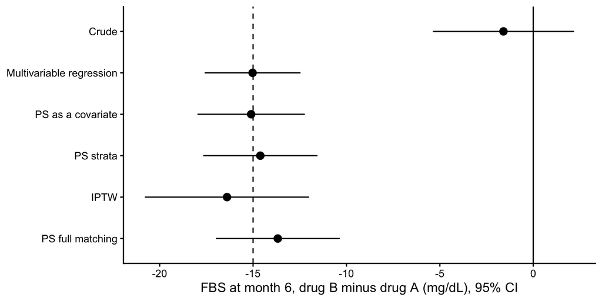

```r
p_effect <- ggplot2::ggplot(
  effect_table,
  ggplot2::aes(
    x = estimate,
    y = forcats::fct_rev(forcats::fct_inorder(method))
  )
) +
  ggplot2::geom_vline(
    xintercept = truth,
    linetype = "dashed"
  ) +
  ggplot2::geom_vline(xintercept = 0) +
  ggplot2::geom_pointrange(
    ggplot2::aes(xmin = conf.low, xmax = conf.high)
  ) +
  ggplot2::labs(
    x = "FBS at month 6, drug B minus drug A (mg/dL), 95% CI",
    y = NULL
  ) +
  ggplot2::theme_classic()

p_effect
```

| Method | What the plot shows |
| --- | --- |
| Crude | Misses the truth and crosses no effect. Confounding by indication. |
| The five adjusted methods | Every 95% CI covers −15 |
| IPTW | The widest CI. A few large weights cost precision, as the effective sample size in chapter 6 warned. |

## 7.12 Step 11: check and save

The checks hold what the simulation promised. Every adjusted CI covers the truth, and the crude CI does not.

```r
adjusted <- effect_table |>
  dplyr::filter(method != "Crude")

stopifnot(
  nrow(effect_table) == 6,
  all(adjusted$conf.low < truth & adjusted$conf.high > truth),
  effect_table$conf.low[effect_table$method == "Crude"] > truth
)

saveRDS(effect_table, path_effect)
```

# Coming next

This site is updated as the workflow grows. The chapters above are what exists so far. The next chapter is planned below.

## Mixed models for the repeated visits

The cleaned data are in long format, with up to five rows per patient. Rows from the same patient are not independent, and chapter 2 showed it with the correlation between visits. A plain regression would treat them as independent. Ignoring the correlation gives the wrong standard errors, often too small for comparisons between arms.

A mixed model fixes this. It gives each patient their own starting level and, if needed, their own slope. It also uses every visit a patient attended. When dropout depends only on values we saw, called missing at random (MAR), this keeps the estimates valid. It does not fix dropout that depends on values we never saw. That is the next chapter.

# Stata to R map

Only commands that the scripts in this workflow use are listed.

| Stata or epicalc command | R equivalent | Chapter |
| --- | --- | --- |
| `import excel` | `readxl::read_excel()` | 1 |
| `tab sex` (epicalc `tab1`) | `epicalc::tab1()` | 2 |
| `tab treatment sex, row col` | `epicalc::tabpct()` | 2 |
| `table1` style baseline table (epicalc `tableStack`) | `epicalc::tableStack()` | 2 |
| `tabstat fbs, by(group) stat(mean sd n)` | `epicalc::aggregate.numeric()` | 2 |
| `histogram fbs, by(month)` | `ggplot2::geom_histogram()` with `facet_wrap()` | 2 |
| `graph box fbs, over(month)` | `ggplot2::geom_boxplot()` | 2 |
| `twoway scatter fbs dm_duration` | `ggplot2::geom_point()` | 4 |
| `twoway line mean_fbs month` | `ggplot2::geom_line()` | 4 |
| `twoway lowess fbs time` | `ggplot2::geom_smooth(method = "loess")` | 4 |
| `twoway lfit fbs time` | `ggplot2::geom_smooth(method = "lm")` | 4 |
| `twoway qfit fbs time` | `ggplot2::geom_smooth(method = "lm", formula = y ~ poly(x, 2))` | 4 |
| `graph bar (mean) fbs, over(month)` | `ggplot2::geom_col()` | 4 |
| `graph export fig.tif` | `ggplot2::ggsave()` | 4 |
| `spearman var1 var2` | `rstatix::cor_test(method = "spearman")` | 2 |
| `duplicates drop` | `dplyr::distinct()` and `dplyr::slice_head()` | 1 |
| `destring` | `readr::parse_number()` | 1 |
| `gen`, `replace` | `dplyr::mutate()` with `if_else()` and `case_when()` | 1 |
| `keep if`, `drop if` | `dplyr::filter()` | 1 |
| `keep`, `sort` | `dplyr::select()` and `dplyr::arrange()` | 1 |
| `reshape long` | `tidyr::pivot_longer()` | 1 |
| `reshape wide` | `tidyr::pivot_wider()` | 2 |
| `date()` and `mdy()` | `lubridate::dmy()` and `lubridate::ymd()` | 1 |
| `assert` | `stopifnot()` | 1 |
| `logit treatment age i.sex bmi ...` | `glm(family = binomial(link = "logit"))` | 5 |
| `predict ps, pr` | `predict(type = "response")` | 5 |
| `gen w = cond(treat, 1/ps, 1/(1-ps))` | `dplyr::mutate()` with `case_when()` | 5 |
| `psgraph`, `twoway histogram ps, by(treat)` | `ggplot2::geom_histogram()` | 5 |
| `tebalance summarize`, `pstest` | `cobalt::bal.tab()` | 6 |
| `tebalance density` | `cobalt::bal.plot()` | 6 |
| `[pweight = w]` | `survey::svydesign(weights = ~weight)` | 6 |
| `regress fbs_m6 i.treatment ... , vce(robust)` with `[pweight = w]` | `survey::svyglm()` | 7 |
| `margins treatment` / `margins r.treatment` | `emmeans::emmeans(counterfactual = )` and `contrast(method = "revpairwise")` | 7 |
| `teffects ipw`, `teffects psmatch` | `survey::svyglm()`, `MatchIt::matchit()` | 7 |
| `xtile ps5 = ps, nq(5)` | `dplyr::ntile(ps, 5)` | 7 |
| `save` | `saveRDS()` | 1 |
| `table1_mc` (user written baseline table) | `gtsummary::tbl_summary()` | 3 |

# References

Allaire, JJ, Yihui Xie, Christophe Dervieux, Jonathan McPherson, Javier Luraschi, Kevin Ushey, Aron Atkins, et al. 2026. *rmarkdown: Dynamic Documents for R*. https://github.com/rstudio/rmarkdown.

Chongsuvivatwong, Virasakdi. 2023. *epicalc: Epidemiological Calculator*. https://medipe.psu.ac.th/epicalc/.

Comtois, Dominic. 2026. *summarytools: Tools to Quickly and Neatly Summarize Data*. https://github.com/dcomtois/summarytools.

Firke, Sam. 2024. *janitor: Simple Tools for Examining and Cleaning Dirty Data*. https://github.com/sfirke/janitor.

Gao, Peter, Ben Schneider, and Stas Kolenkikov. 2026. *survey: Analysis of Complex Survey Samples*. http://r-survey.r-forge.r-project.org/survey/.

Greifer, Noah. 2026. *cobalt: Covariate Balance Tables and Plots*. https://ngreifer.github.io/cobalt/.

Hansen, Ben, Mark Fredrickson, Josh Errickson, and Josh Buckner. 2024. *optmatch: Functions for Optimal Matching*. http://optmat.ch.

Ho, Daniel, Kosuke Imai, Gary King, Elizabeth Stuart, and Noah Greifer. 2025. *MatchIt: Nonparametric Preprocessing for Parametric Causal Inference*. https://kosukeimai.github.io/MatchIt/.

Iannone, Richard, Joe Cheng, Barret Schloerke, Shannon Haughton, Ellis Hughes, Alexandra Lauer, Romain François, JooYoung Seo, Ken Brevoort, and Olivier Roy. 2026. *gt: Easily Create Presentation-Ready Display Tables*. https://gt.rstudio.com.

Kassambara, Alboukadel. 2026. *rstatix: Pipe-Friendly Framework for Basic Statistical Tests*. https://rpkgs.datanovia.com/rstatix/.

Lenth, Russell V., and Julia Piaskowski. 2026. *emmeans: Estimated Marginal Means, aka Least-Squares Means*. https://rvlenth.github.io/emmeans/.

Pedersen, Thomas Lin, and Maxim Shemanarev. 2026. *ragg: Graphic Devices Based on AGG*. https://ragg.r-lib.org.

R Core Team. 2026. *R: A Language and Environment for Statistical Computing*. Vienna, Austria: R Foundation for Statistical Computing. https://doi.org/10.32614/R.manuals.

Robinson, David, Alex Hayes, Simon Couch, and Emil Hvitfeldt. 2026. *broom: Convert Statistical Objects into Tidy Tibbles*. https://broom.tidymodels.org/.

Sjoberg, Daniel D., Joseph Larmarange, Michael Curry, Emily de la Rua, Jessica Lavery, Karissa Whiting, and Emily C. Zabor. 2026. *gtsummary: Presentation-Ready Data Summary and Analytic Result Tables*. https://github.com/ddsjoberg/gtsummary.

Spinu, Vitalie, Garrett Grolemund, and Hadley Wickham. 2026. *lubridate: Make Dealing with Dates a Little Easier*. https://lubridate.tidyverse.org.

Wickham, Hadley. 2025a. *forcats: Tools for Working with Categorical Variables (Factors)*. https://forcats.tidyverse.org/.

———. 2025b. *stringr: Simple, Consistent Wrappers for Common String Operations*. https://stringr.tidyverse.org.

Wickham, Hadley, and Jennifer Bryan. 2026. *readxl: Read Excel Files*. https://readxl.tidyverse.org.

Wickham, Hadley, Winston Chang, Lionel Henry, Thomas Lin Pedersen, Kohske Takahashi, Claus Wilke, Kara Woo, Hiroaki Yutani, Dewey Dunnington, and Teun van den Brand. 2026. *ggplot2: Create Elegant Data Visualisations Using the Grammar of Graphics*. https://ggplot2.tidyverse.org.

Wickham, Hadley, Romain François, Lionel Henry, Kirill Müller, and Davis Vaughan. 2026. *dplyr: A Grammar of Data Manipulation*. https://dplyr.tidyverse.org.

Wickham, Hadley, Jim Hester, and Jennifer Bryan. 2026. *readr: Read Rectangular Text Data*. https://readr.tidyverse.org.

Wickham, Hadley, Davis Vaughan, and Maximilian Girlich. 2025. *tidyr: Tidy Messy Data*. https://tidyr.tidyverse.org.

Xie, Yihui. 2025. *knitr: A General-Purpose Package for Dynamic Report Generation in R*. https://yihui.org/knitr/.

Zeileis, Achim, and Thomas Lumley. 2026. *sandwich: Robust Covariance Matrix Estimators*. https://sandwich.R-Forge.R-project.org/.